# Project: Wrangling and Analyze Data

## TABLE OF CONTENT

**1. Data Gathering**  
**2. Assessing Data**  
2.1 Visual Assessment  
2.2 Programmatic Assessment  
**3. Cleaning Data**  
3.1 Tidiness  
3.2 Quality  
**4. Storing Data**  
**5. Analyzing and Visualizing Data**

## Data Gathering

```python
import pandas as pd
import numpy as np
import matplotlib.pyplot as plt
%matplotlib inline
import seaborn as sns
import requests
import os
import json
import tweepy
import requests
# from PIL import Image
# from io import BytesIO

twitter_enhanced = pd.read_csv('twitter-archive-enhanced.csv')
```

1. Use the Requests library to download the tweet image prediction (image_predictions.tsv)

```python
url = 'https://d17h27t6h515a5.cloudfront.net/topher/2017/August/599fd2ad_image-predictions/image-predictions.tsv'
response = requests.get(url)

with open('image-predictions.tsv', mode = 'wb') as file:
    file.write(response.content)
```

```python
image= pd.read_csv('image-predictions.tsv', sep = '\t')
image.head()
```

|  | tweet_id | jpg_url | img_num | p1 | p1_conf | p1_dog | p2 | p2_conf | p2_dog | p3 | p3_conf | p3_dog |
| --- | --- | --- | --- | --- | --- | --- | --- | --- | --- | --- | --- | --- |
| 0 | 666020888022790149 | https://pbs.twimg.com/media/CT4udn0WwAA0aMy.jpg | 1 | Welsh_springer_spaniel | 0.465074 | True | collie | 0.156665 | True | Shetland_sheepdog | 0.061428 | True |
| 1 | 666029285002620928 | https://pbs.twimg.com/media/CT42GRgUYAA5iDo.jpg | 1 | redbone | 0.506826 | True | miniature_pinscher | 0.074192 | True | Rhodesian_ridgeback | 0.072010 | True |
| 2 | 666033412701032449 | https://pbs.twimg.com/media/CT4521TWwAEvMyu.jpg | 1 | German_shepherd | 0.596461 | True | malinois | 0.138584 | True | bloodhound | 0.116197 | True |
| 3 | 666044226329800704 | https://pbs.twimg.com/media/CT5Dr8HUEAA-lEu.jpg | 1 | Rhodesian_ridgeback | 0.408143 | True | redbone | 0.360687 | True | miniature_pinscher | 0.222752 | True |
| 4 | 666049248165822465 | https://pbs.twimg.com/media/CT5IQmsXIAAKY4A.jpg | 1 | miniature_pinscher | 0.560311 | True | Rottweiler | 0.243682 | True | Doberman | 0.154629 | True |

1. Use the Tweepy library to query additional data via the Twitter API (tweet_json.txt)

```python
consumer_key = ''
consumer_secret = ''
access_token = ''
access_secret = ''

from tweepy import OAuthHandler

auth = tweepy.OAuthHandler(consumer_key, consumer_secret)
auth.set_access_token(access_token, access_secret)

api = tweepy.API(auth,wait_on_rate_limit=True,wait_on_rate_limit_notify=True)
```

```python
"""
tweet_ids = twitter_enhanced.tweet_id.values
len(tweet_ids)

from timeit import default_timer as timer
count = 0
fails_dict = {}
start = timer()
# Save each tweet's returned JSON as a new line in a .txt file
with open('tweet_json.txt', 'w') as outfile:
    # This loop will likely take 20-30 minutes to run because of Twitter's rate limit
    for tweet_id in tweet_ids:
        count += 1
        print(str(count) + ": " + str(tweet_id))
        try:
            tweet = api.get_status(tweet_id, tweet_mode='extended')
            print("Success")
            json.dump(tweet._json, outfile)
            outfile.write('\n')
        except tweepy.TweepException as e:
            print("Fail")
            fails_dict[tweet_id] = e
            pass
end = timer()
print(end - start)
print(fails_dict)

"""
```

[output not shown]

```python
tweets_list = []
with open('tweet_json.txt', 'r') as file:
    for line in file:
        data = json.loads(line)
        tweet_id = data['id']
        tweet = data['full_text']
        retweet_count = data['retweet_count']
        favorite_count = data['favorite_count']
        created_at = data['created_at']
        source = data['source']
        tweets_list.append({'tweet_id' : tweet_id,
                            'tweet' : tweet,
                           'retweet_count' : retweet_count,
                           'favorite_count' : favorite_count,
                           'created_at': created_at,
                           'source': source})
df = pd.DataFrame(tweets_list)
```

## Assessing Data

### Visual Assessment

```python
twitter_enhanced.sample(10)
```

|  | tweet_id | in_reply_to_status_id | in_reply_to_user_id | timestamp | source | text | retweeted_status_id | retweeted_status_user_id | retweeted_status_timestamp | expanded_urls | rating_numerator | rating_denominator | name | doggo | floofer | pupper | puppo |
| --- | --- | --- | --- | --- | --- | --- | --- | --- | --- | --- | --- | --- | --- | --- | --- | --- | --- |
| 1782 | 677687604918272002 | NaN | NaN | 2015-12-18 03:11:30 +0000 | <a href="http://twitter.com/download/iphone" r... | This was Cindy's face when she heard Susan for... | NaN | NaN | NaN | https://twitter.com/dog_rates/status/677687604... | 11 | 10 | None | None | None | None | None |
| 2178 | 669015743032369152 | NaN | NaN | 2015-11-24 04:52:37 +0000 | <a href="http://twitter.com/download/iphone" r... | Super rare dog right here guys. Doesn't bark. ... | NaN | NaN | NaN | https://twitter.com/dog_rates/status/669015743... | 10 | 10 | None | None | None | None | None |
| 1712 | 680494726643068929 | NaN | NaN | 2015-12-25 21:06:00 +0000 | <a href="http://twitter.com/download/iphone" r... | Here we have uncovered an entire battalion of ... | NaN | NaN | NaN | https://twitter.com/dog_rates/status/680494726... | 26 | 10 | None | None | None | None | None |
| 1502 | 692041934689402880 | NaN | NaN | 2016-01-26 17:50:29 +0000 | <a href="http://vine.co" rel="nofollow">Vine -... | This is Teddy. His head is too heavy. 13/10 (v... | NaN | NaN | NaN | https://vine.co/v/iiI3wmqXYmA | 13 | 10 | Teddy | None | None | None | None |
| 1544 | 689517482558820352 | NaN | NaN | 2016-01-19 18:39:13 +0000 | <a href="http://twitter.com/download/iphone" r... | This is Carl. He just wants to make sure you'r... | NaN | NaN | NaN | https://twitter.com/dog_rates/status/689517482... | 12 | 10 | Carl | None | None | None | None |
| 1874 | 675135153782571009 | NaN | NaN | 2015-12-11 02:08:58 +0000 | <a href="http://twitter.com/download/iphone" r... | This is Steven. He got locked outside. Damn it... | NaN | NaN | NaN | https://twitter.com/dog_rates/status/675135153... | 5 | 10 | Steven | None | None | None | None |
| 2076 | 670838202509447168 | NaN | NaN | 2015-11-29 05:34:25 +0000 | <a href="http://twitter.com/download/iphone" r... | Pink dogs here. Unreasonably long necks. Left ... | NaN | NaN | NaN | https://twitter.com/dog_rates/status/670838202... | 4 | 10 | None | None | None | None | None |
| 808 | 771770456517009408 | NaN | NaN | 2016-09-02 18:03:10 +0000 | <a href="http://twitter.com/download/iphone" r... | This is Davey. He'll have your daughter home b... | NaN | NaN | NaN | https://twitter.com/dog_rates/status/771770456... | 11 | 10 | Davey | None | None | None | None |
| 1780 | 677700003327029250 | NaN | NaN | 2015-12-18 04:00:46 +0000 | <a href="http://twitter.com/download/iphone" r... | This is Ralph. He's an interpretive dancer. 10... | NaN | NaN | NaN | https://twitter.com/dog_rates/status/677700003... | 10 | 10 | Ralph | None | None | None | None |
| 44 | 883838122936631299 | NaN | NaN | 2017-07-09 00:00:04 +0000 | <a href="http://twitter.com/download/iphone" r... | This is Noah. He can't believe someone made th... | NaN | NaN | NaN | https://twitter.com/dog_rates/status/883838122... | 12 | 10 | Noah | None | None | None | None |

```python
image.sample(10)
```

|  | tweet_id | jpg_url | img_num | p1 | p1_conf | p1_dog | p2 | p2_conf | p2_dog | p3 | p3_conf | p3_dog |
| --- | --- | --- | --- | --- | --- | --- | --- | --- | --- | --- | --- | --- |
| 346 | 672466075045466113 | https://pbs.twimg.com/media/CVUUU_EWoAAxABV.jpg | 1 | cocker_spaniel | 0.150424 | True | toy_poodle | 0.088605 | True | Welsh_springer_spaniel | 0.072014 | True |
| 1541 | 791026214425268224 | https://pbs.twimg.com/media/CpmyNumW8AAAJGj.jpg | 1 | malamute | 0.375098 | True | jean | 0.069362 | False | keeshond | 0.050528 | True |
| 449 | 674737130913071104 | https://pbs.twimg.com/media/CV0l10AU8AAfg-a.jpg | 1 | Pomeranian | 0.948537 | True | schipperke | 0.014310 | True | Chihuahua | 0.008120 | True |
| 895 | 699446877801091073 | https://pbs.twimg.com/media/CbTvNpoW0AEemnx.jpg | 3 | Pembroke | 0.969400 | True | Cardigan | 0.026059 | True | Chihuahua | 0.003505 | True |
| 646 | 681654059175129088 | https://pbs.twimg.com/media/CXW4wGHWsAE_eBD.jpg | 1 | Pomeranian | 0.800538 | True | chow | 0.146892 | True | Pekinese | 0.037613 | True |
| 481 | 675362609739206656 | https://pbs.twimg.com/media/CV9etctWUAAl5Hp.jpg | 1 | Labrador_retriever | 0.479008 | True | ice_bear | 0.218289 | False | kuvasz | 0.139911 | True |
| 1008 | 709207347839836162 | https://pbs.twimg.com/media/CdecUSzUIAAHCvg.jpg | 1 | Chihuahua | 0.948323 | True | Italian_greyhound | 0.017730 | True | quilt | 0.016688 | False |
| 874 | 698178924120031232 | https://pbs.twimg.com/media/CbBuBhbWwAEGH29.jpg | 1 | Chesapeake_Bay_retriever | 0.351868 | True | malinois | 0.207753 | True | Labrador_retriever | 0.154606 | True |
| 130 | 668291999406125056 | https://pbs.twimg.com/media/CUZABzGW4AE5F0k.jpg | 1 | web_site | 0.995535 | False | skunk | 0.001363 | False | badger | 0.000686 | False |
| 836 | 694206574471057408 | https://pbs.twimg.com/media/CaJRMPQWIAA1zL9.jpg | 1 | Shih-Tzu | 0.352547 | True | toy_poodle | 0.155720 | True | Maltese_dog | 0.116657 | True |

```python
df.sample(10)
```

|  | created_at | favorite_count | retweet_count | source | tweet | tweet_id |
| --- | --- | --- | --- | --- | --- | --- |
| 2034 | Mon Nov 30 02:52:03 +0000 2015 | 313 | 68 | <a href="http://twitter.com/download/iphone" r... | This is Anthony. He just finished up his maste... | 671159727754231808 |
| 268 | Tue Mar 07 22:22:32 +0000 2017 | 25263 | 5947 | <a href="http://twitter.com/download/iphone" r... | This is Odie. He's big. 13/10 would attempt to... | 839239871831150596 |
| 718 | Tue Sep 27 16:06:28 +0000 2016 | 5197 | 1201 | <a href="http://twitter.com/download/iphone" r... | This is Koda. He has a weird relationship with... | 780800785462489090 |
| 941 | Tue Jul 05 01:00:05 +0000 2016 | 3373 | 1183 | <a href="http://twitter.com/download/iphone" r... | This is Stewie. He will roundhouse kick anyone... | 750132105863102464 |
| 366 | Thu Feb 02 01:01:21 +0000 2017 | 20330 | 4613 | <a href="http://twitter.com/download/iphone" r... | This is Loki. He smiles like Elvis. Ain't noth... | 826958653328592898 |
| 776 | Mon Sep 05 19:22:09 +0000 2016 | 8049 | 3578 | <a href="http://twitter.com" rel="nofollow">Tw... | You need to watch these two doggos argue throu... | 772877495989305348 |
| 1378 | Mon Feb 15 04:31:20 +0000 2016 | 2091 | 565 | <a href="http://twitter.com/download/iphone" r... | This is Charl. He's a bully. Chucks that dumbb... | 699088579889332224 |
| 1244 | Mon Mar 14 03:50:21 +0000 2016 | 2215 | 522 | <a href="http://twitter.com/download/iphone" r... | This is Walker. He's a Butternut Khalifa. Appe... | 709225125749587968 |
| 2250 | Thu Nov 19 18:13:27 +0000 2015 | 411 | 197 | <a href="http://twitter.com/download/iphone" r... | This is Biden. Biden just tripped... 7/10 http... | 667405339315146752 |
| 2284 | Tue Nov 17 22:06:57 +0000 2015 | 209 | 60 | <a href="http://twitter.com/download/iphone" r... | This is Lugan. He is a Bohemian Rhapsody. Very... | 666739327293083650 |

### Programmatic Assessment

#### Twitter_enhanced Dataset

```python
## Twitter enhanced
twitter_enhanced.info()
```

```
<class 'pandas.core.frame.DataFrame'>
RangeIndex: 2356 entries, 0 to 2355
Data columns (total 17 columns):
tweet_id                      2356 non-null int64
in_reply_to_status_id         78 non-null float64
in_reply_to_user_id           78 non-null float64
timestamp                     2356 non-null object
source                        2356 non-null object
text                          2356 non-null object
retweeted_status_id           181 non-null float64
retweeted_status_user_id      181 non-null float64
retweeted_status_timestamp    181 non-null object
expanded_urls                 2297 non-null object
rating_numerator              2356 non-null int64
rating_denominator            2356 non-null int64
name                          2356 non-null object
doggo                         2356 non-null object
floofer                       2356 non-null object
pupper                        2356 non-null object
puppo                         2356 non-null object
dtypes: float64(4), int64(3), object(10)
memory usage: 313.0+ KB
```

```python
twitter_enhanced.describe()
```

|  | tweet_id | in_reply_to_status_id | in_reply_to_user_id | retweeted_status_id | retweeted_status_user_id | rating_numerator | rating_denominator |
| --- | --- | --- | --- | --- | --- | --- | --- |
| count | 2.356000e+03 | 7.800000e+01 | 7.800000e+01 | 1.810000e+02 | 1.810000e+02 | 2356.000000 | 2356.000000 |
| mean | 7.427716e+17 | 7.455079e+17 | 2.014171e+16 | 7.720400e+17 | 1.241698e+16 | 13.126486 | 10.455433 |
| std | 6.856705e+16 | 7.582492e+16 | 1.252797e+17 | 6.236928e+16 | 9.599254e+16 | 45.876648 | 6.745237 |
| min | 6.660209e+17 | 6.658147e+17 | 1.185634e+07 | 6.661041e+17 | 7.832140e+05 | 0.000000 | 0.000000 |
| 25% | 6.783989e+17 | 6.757419e+17 | 3.086374e+08 | 7.186315e+17 | 4.196984e+09 | 10.000000 | 10.000000 |
| 50% | 7.196279e+17 | 7.038708e+17 | 4.196984e+09 | 7.804657e+17 | 4.196984e+09 | 11.000000 | 10.000000 |
| 75% | 7.993373e+17 | 8.257804e+17 | 4.196984e+09 | 8.203146e+17 | 4.196984e+09 | 12.000000 | 10.000000 |
| max | 8.924206e+17 | 8.862664e+17 | 8.405479e+17 | 8.874740e+17 | 7.874618e+17 | 1776.000000 | 170.000000 |

```python
twitter_enhanced['name'].value_counts()
```

```
None              745
a                  55
Charlie            12
Cooper             11
Oliver             11
Lucy               11
Penny              10
Lola               10
Tucker             10
Bo                  9
Winston             9
Sadie               8
the                 8
Daisy               7
Bailey              7
an                  7
Toby                7
Buddy               7
Scout               6
Koda                6
Oscar               6
Leo                 6
Jax                 6
Rusty               6
Bella               6
Stanley             6
Milo                6
Jack                6
Dave                6
Bentley             5
                 ...
Lassie              1
Bruiser             1
Jay                 1
Jazz                1
Skittle             1
Swagger             1
Bubba               1
Charleson           1
Huxley              1
Leonard             1
Eleanor             1
Oddie               1
Iggy                1
Vince               1
Derby               1
Michelangelope      1
infuriating         1
Darla               1
Traviss             1
Nida                1
Blanket             1
Sid                 1
Goliath             1
Oreo                1
Nugget              1
Liam                1
Lolo                1
Yukon               1
Fillup              1
Tonks               1
Name: name, Length: 957, dtype: int64
```

```python
twitter_enhanced['doggo'].value_counts()
```

```
None     2259
doggo      97
Name: doggo, dtype: int64
```

```python
twitter_enhanced[twitter_enhanced['rating_denominator'] > 100]
```

|  | tweet_id | in_reply_to_status_id | in_reply_to_user_id | timestamp | source | text | retweeted_status_id | retweeted_status_user_id | retweeted_status_timestamp | expanded_urls | rating_numerator | rating_denominator | name | doggo | floofer | pupper | puppo |
| --- | --- | --- | --- | --- | --- | --- | --- | --- | --- | --- | --- | --- | --- | --- | --- | --- | --- |
| 902 | 758467244762497024 | NaN | NaN | 2016-07-28 01:00:57 +0000 | <a href="http://twitter.com/download/iphone" r... | Why does this never happen at my front door...... | NaN | NaN | NaN | https://twitter.com/dog_rates/status/758467244... | 165 | 150 | None | None | None | None | None |
| 1120 | 731156023742988288 | NaN | NaN | 2016-05-13 16:15:54 +0000 | <a href="http://twitter.com/download/iphone" r... | Say hello to this unbelievably well behaved sq... | NaN | NaN | NaN | https://twitter.com/dog_rates/status/731156023... | 204 | 170 | this | None | None | None | None |
| 1634 | 684225744407494656 | 6.842229e+17 | 4.196984e+09 | 2016-01-05 04:11:44 +0000 | <a href="http://twitter.com/download/iphone" r... | Two sneaky puppers were not initially seen, mo... | NaN | NaN | NaN | https://twitter.com/dog_rates/status/684225744... | 143 | 130 | None | None | None | None | None |
| 1635 | 684222868335505415 | NaN | NaN | 2016-01-05 04:00:18 +0000 | <a href="http://twitter.com/download/iphone" r... | Someone help the girl is being mugged. Several... | NaN | NaN | NaN | https://twitter.com/dog_rates/status/684222868... | 121 | 110 | None | None | None | None | None |
| 1779 | 677716515794329600 | NaN | NaN | 2015-12-18 05:06:23 +0000 | <a href="http://twitter.com/download/iphone" r... | IT'S PUPPERGEDDON. Total of 144/120 ...I think... | NaN | NaN | NaN | https://twitter.com/dog_rates/status/677716515... | 144 | 120 | None | None | None | None | None |

```python
twitter_enhanced['rating_numerator'].value_counts()
```

```
12      558
11      464
10      461
13      351
9       158
8       102
7        55
14       54
5        37
6        32
3        19
4        17
1         9
2         9
420       2
```

[output cut: 26 more lines]

```python
twitter_enhanced['source'].value_counts()
```

```
<a href="http://twitter.com/download/iphone" rel="nofollow">Twitter for iPhone</a>     2221
<a href="http://vine.co" rel="nofollow">Vine - Make a Scene</a>                          91
<a href="http://twitter.com" rel="nofollow">Twitter Web Client</a>                       33
<a href="https://about.twitter.com/products/tweetdeck" rel="nofollow">TweetDeck</a>      11
Name: source, dtype: int64
```

```python
twitter_enhanced['retweeted_status_timestamp'].isnull().sum()
```

```
2175
```

```python
len(twitter_enhanced[twitter_enhanced['in_reply_to_status_id'] >= 0])
```

```
78
```

```python
len(twitter_enhanced[twitter_enhanced['in_reply_to_user_id'] >= 0])
```

```
78
```

```python
len(twitter_enhanced[twitter_enhanced['retweeted_status_id'] >= 0])
```

```
181
```

```python
len(twitter_enhanced[twitter_enhanced['retweeted_status_user_id'] >= 0])
```

```
181
```

#### Image Dataset

```python
image.head()
```

|  | tweet_id | jpg_url | img_num | p1 | p1_conf | p1_dog | p2 | p2_conf | p2_dog | p3 | p3_conf | p3_dog |
| --- | --- | --- | --- | --- | --- | --- | --- | --- | --- | --- | --- | --- |
| 0 | 666020888022790149 | https://pbs.twimg.com/media/CT4udn0WwAA0aMy.jpg | 1 | Welsh_springer_spaniel | 0.465074 | True | collie | 0.156665 | True | Shetland_sheepdog | 0.061428 | True |
| 1 | 666029285002620928 | https://pbs.twimg.com/media/CT42GRgUYAA5iDo.jpg | 1 | redbone | 0.506826 | True | miniature_pinscher | 0.074192 | True | Rhodesian_ridgeback | 0.072010 | True |
| 2 | 666033412701032449 | https://pbs.twimg.com/media/CT4521TWwAEvMyu.jpg | 1 | German_shepherd | 0.596461 | True | malinois | 0.138584 | True | bloodhound | 0.116197 | True |
| 3 | 666044226329800704 | https://pbs.twimg.com/media/CT5Dr8HUEAA-lEu.jpg | 1 | Rhodesian_ridgeback | 0.408143 | True | redbone | 0.360687 | True | miniature_pinscher | 0.222752 | True |
| 4 | 666049248165822465 | https://pbs.twimg.com/media/CT5IQmsXIAAKY4A.jpg | 1 | miniature_pinscher | 0.560311 | True | Rottweiler | 0.243682 | True | Doberman | 0.154629 | True |

```python
image.info()
```

```
<class 'pandas.core.frame.DataFrame'>
RangeIndex: 2075 entries, 0 to 2074
Data columns (total 12 columns):
tweet_id    2075 non-null int64
jpg_url     2075 non-null object
img_num     2075 non-null int64
p1          2075 non-null object
p1_conf     2075 non-null float64
p1_dog      2075 non-null bool
p2          2075 non-null object
p2_conf     2075 non-null float64
p2_dog      2075 non-null bool
p3          2075 non-null object
p3_conf     2075 non-null float64
p3_dog      2075 non-null bool
dtypes: bool(3), float64(3), int64(2), object(4)
memory usage: 152.1+ KB
```

```python
image.describe()
```

|  | tweet_id | img_num | p1_conf | p2_conf | p3_conf |
| --- | --- | --- | --- | --- | --- |
| count | 2.075000e+03 | 2075.000000 | 2075.000000 | 2.075000e+03 | 2.075000e+03 |
| mean | 7.384514e+17 | 1.203855 | 0.594548 | 1.345886e-01 | 6.032417e-02 |
| std | 6.785203e+16 | 0.561875 | 0.271174 | 1.006657e-01 | 5.090593e-02 |
| min | 6.660209e+17 | 1.000000 | 0.044333 | 1.011300e-08 | 1.740170e-10 |
| 25% | 6.764835e+17 | 1.000000 | 0.364412 | 5.388625e-02 | 1.622240e-02 |
| 50% | 7.119988e+17 | 1.000000 | 0.588230 | 1.181810e-01 | 4.944380e-02 |
| 75% | 7.932034e+17 | 1.000000 | 0.843855 | 1.955655e-01 | 9.180755e-02 |
| max | 8.924206e+17 | 4.000000 | 1.000000 | 4.880140e-01 | 2.734190e-01 |

```python
image['img_num'].value_counts()
```

```
1    1780
2     198
3      66
4      31
Name: img_num, dtype: int64
```

```python
image['jpg_url'].duplicated().sum()
```

```
66
```

#### Tweet_JSON Dataset

```python
df.head()
```

|  | created_at | favorite_count | retweet_count | source | tweet | tweet_id |
| --- | --- | --- | --- | --- | --- | --- |
| 0 | Tue Aug 01 16:23:56 +0000 2017 | 33803 | 7002 | <a href="http://twitter.com/download/iphone" r... | This is Phineas. He's a mystical boy. Only eve... | 892420643555336193 |
| 1 | Tue Aug 01 00:17:27 +0000 2017 | 29318 | 5300 | <a href="http://twitter.com/download/iphone" r... | This is Tilly. She's just checking pup on you.... | 892177421306343426 |
| 2 | Mon Jul 31 00:18:03 +0000 2017 | 22045 | 3477 | <a href="http://twitter.com/download/iphone" r... | This is Archie. He is a rare Norwegian Pouncin... | 891815181378084864 |
| 3 | Sun Jul 30 15:58:51 +0000 2017 | 36926 | 7224 | <a href="http://twitter.com/download/iphone" r... | This is Darla. She commenced a snooze mid meal... | 891689557279858688 |
| 4 | Sat Jul 29 16:00:24 +0000 2017 | 35309 | 7756 | <a href="http://twitter.com/download/iphone" r... | This is Franklin. He would like you to stop ca... | 891327558926688256 |

```python
df.info()
```

```
<class 'pandas.core.frame.DataFrame'>
RangeIndex: 2327 entries, 0 to 2326
Data columns (total 6 columns):
created_at        2327 non-null object
favorite_count    2327 non-null int64
retweet_count     2327 non-null int64
source            2327 non-null object
tweet             2327 non-null object
tweet_id          2327 non-null int64
dtypes: int64(3), object(3)
memory usage: 109.2+ KB
```

```python
df.describe()
```

|  | favorite_count | retweet_count | tweet_id |
| --- | --- | --- | --- |
| count | 2327.000000 | 2327.000000 | 2.327000e+03 |
| mean | 7052.284486 | 2469.957886 | 7.417930e+17 |
| std | 10959.526756 | 4182.980216 | 6.820795e+16 |
| min | 0.000000 | 1.000000 | 6.660209e+17 |
| 25% | 1225.000000 | 493.500000 | 6.781394e+17 |
| 50% | 3051.000000 | 1148.000000 | 7.178418e+17 |
| 75% | 8600.500000 | 2860.000000 | 7.986547e+17 |
| max | 144826.000000 | 70696.000000 | 8.924206e+17 |

```python
df['source'].value_counts()
```

```
<a href="http://twitter.com/download/iphone" rel="nofollow">Twitter for iPhone</a>     2193
<a href="http://vine.co" rel="nofollow">Vine - Make a Scene</a>                          91
<a href="http://twitter.com" rel="nofollow">Twitter Web Client</a>                       33
<a href="https://about.twitter.com/products/tweetdeck" rel="nofollow">TweetDeck</a>      10
Name: source, dtype: int64
```

```python
""" Twitter Enhanced






Image





df("Tweet_JSON")

- iphone seems to be the major source of the data, the rest cannot be properly
interpreted


"""
```

```
' Twitter Enhanced\n\n\n\n\n\n\nImage\n\n\n\n\n\ndf("Tweet_JSON")\n\n- iphone seems to be the major source of the data, the rest cannot be properly\ninterpreted\n\n\n'
```

### Tidiness issues

1. Information about one type of observational unit (tweets) is spread across three different files/dataframes i.e "doggo","floofer","pupper","puppo", should be melted into a single column (Twitter_enhanced)
2. Source and tweet columns duplicated in twitter_enhanced and df table.
3. Created_at (df) - day of the week should be separated from the time of occurrence. Created_at should be dropped as well to prevent date duplication (in tw_enhanced and df)
4. Separate date from the hours,minutes in twitter_enhanced
5. Let tweet_id be the first column in the df table
6. Tweet_id in twitter_enhanced duplicated in the image and df tables
7. Tweet_JSON (df) shoud be part of twitter_enhanced. Infact, if possible, all three should be combined into one.

## Cleaning Data

```python
# Make copies of original pieces of data
tw_clean = twitter_enhanced.copy()
image_clean = image.copy()
df_clean = df.copy()
```

## Tidiness

### Issue #1:

"doggo","floofer","pupper","puppo", should be melted into a single column (Twitter_enhanced)

#### Define:

Join the three columns -Replace all None with empty and concatenate

#### Code

```python
dog_class = ["doggo","floofer","pupper","puppo"]

for i in dog_class:
    tw_clean[i] = tw_clean[i].replace('None', '')

tw_clean['dog_class'] = tw_clean["doggo"]+tw_clean["floofer"]+tw_clean["pupper"]+tw_clean["puppo"]
```

```python
# drop the redundant colomns
tw_clean.drop(['doggo','floofer','pupper','puppo'], axis = 1, inplace = True)
# Replace the empty ones with np.nan
tw_clean['dog_class'] = tw_clean['dog_class'].replace('', np.nan)
```

#### Test

```python
tw_clean.head()
```

|  | tweet_id | in_reply_to_status_id | in_reply_to_user_id | timestamp | source | text | retweeted_status_id | retweeted_status_user_id | retweeted_status_timestamp | expanded_urls | rating_numerator | rating_denominator | name | dog_class |
| --- | --- | --- | --- | --- | --- | --- | --- | --- | --- | --- | --- | --- | --- | --- |
| 0 | 892420643555336193 | NaN | NaN | 2017-08-01 16:23:56 +0000 | <a href="http://twitter.com/download/iphone" r... | This is Phineas. He's a mystical boy. Only eve... | NaN | NaN | NaN | https://twitter.com/dog_rates/status/892420643... | 13 | 10 | Phineas | NaN |
| 1 | 892177421306343426 | NaN | NaN | 2017-08-01 00:17:27 +0000 | <a href="http://twitter.com/download/iphone" r... | This is Tilly. She's just checking pup on you.... | NaN | NaN | NaN | https://twitter.com/dog_rates/status/892177421... | 13 | 10 | Tilly | NaN |
| 2 | 891815181378084864 | NaN | NaN | 2017-07-31 00:18:03 +0000 | <a href="http://twitter.com/download/iphone" r... | This is Archie. He is a rare Norwegian Pouncin... | NaN | NaN | NaN | https://twitter.com/dog_rates/status/891815181... | 12 | 10 | Archie | NaN |
| 3 | 891689557279858688 | NaN | NaN | 2017-07-30 15:58:51 +0000 | <a href="http://twitter.com/download/iphone" r... | This is Darla. She commenced a snooze mid meal... | NaN | NaN | NaN | https://twitter.com/dog_rates/status/891689557... | 13 | 10 | Darla | NaN |
| 4 | 891327558926688256 | NaN | NaN | 2017-07-29 16:00:24 +0000 | <a href="http://twitter.com/download/iphone" r... | This is Franklin. He would like you to stop ca... | NaN | NaN | NaN | https://twitter.com/dog_rates/status/891327558... | 12 | 10 | Franklin | NaN |

```python
tw_clean['dog_class'].value_counts()
```

```
pupper          245
doggo            83
puppo            29
doggopupper      12
floofer           9
doggopuppo        1
doggofloofer      1
Name: dog_class, dtype: int64
```

```python
"""Most are calssified as puppers and we some given two classes...Let's deal with this by replacing
doggopuppo with puppo (the lower class)
doggofloofer with floofer (the lower class)
doggopupper with doggo (just to reduce skewness)
"""

tw_clean['dog_class'].replace("doggopuppo", "puppo", inplace = True)
tw_clean['dog_class'].replace("doggofloofer", "floofer", inplace = True)
tw_clean['dog_class'].replace("doggopupper", "doggo", inplace = True)
```

```python
tw_clean['dog_class'].value_counts()
## skewnesss has been reduced and all dogs have a specific class.
```

```
pupper     245
doggo       95
puppo       30
floofer     10
Name: dog_class, dtype: int64
```

### Issue #2:

Source and tweet duplicated in twitter_enhanced and df table.

#### Define:

Drop the source and tweet column in df. this is because tw_clean contains all the data present in df

```python
tw_clean['source'].value_counts()
```

```
<a href="http://twitter.com/download/iphone" rel="nofollow">Twitter for iPhone</a>     2221
<a href="http://vine.co" rel="nofollow">Vine - Make a Scene</a>                          91
<a href="http://twitter.com" rel="nofollow">Twitter Web Client</a>                       33
<a href="https://about.twitter.com/products/tweetdeck" rel="nofollow">TweetDeck</a>      11
Name: source, dtype: int64
```

```python
df_clean['source'].value_counts()
```

```
<a href="http://twitter.com/download/iphone" rel="nofollow">Twitter for iPhone</a>     2193
<a href="http://vine.co" rel="nofollow">Vine - Make a Scene</a>                          91
<a href="http://twitter.com" rel="nofollow">Twitter Web Client</a>                       33
<a href="https://about.twitter.com/products/tweetdeck" rel="nofollow">TweetDeck</a>      10
Name: source, dtype: int64
```

#### Code

```python
df_clean.drop(['source','tweet'], axis =1, inplace = True)
```

#### Test

```python
df_clean.head()
```

|  | created_at | favorite_count | retweet_count | tweet_id |
| --- | --- | --- | --- | --- |
| 0 | Tue Aug 01 16:23:56 +0000 2017 | 33803 | 7002 | 892420643555336193 |
| 1 | Tue Aug 01 00:17:27 +0000 2017 | 29318 | 5300 | 892177421306343426 |
| 2 | Mon Jul 31 00:18:03 +0000 2017 | 22045 | 3477 | 891815181378084864 |
| 3 | Sun Jul 30 15:58:51 +0000 2017 | 36926 | 7224 | 891689557279858688 |
| 4 | Sat Jul 29 16:00:24 +0000 2017 | 35309 | 7756 | 891327558926688256 |

### Issue #3:

Created_at (df) - day of the week should be separated from the time of occurrence.

#### Define:

Extract the first three characters in the string and drop the created_at column. The date part is already present in the tw_clean dataframe which could translate to having duplicated columns later

#### Code

```python
df_clean['weekday'] = np.nan
for i in range(len(df_clean['created_at'])):
    df_clean['weekday'][i] = df_clean['created_at'][i][0:3]
```

```python
df_clean.drop('created_at', axis = 1, inplace = True)
```

#### Test

```python
df_clean.head()
```

|  | favorite_count | retweet_count | tweet_id | weekday |
| --- | --- | --- | --- | --- |
| 0 | 33803 | 7002 | 892420643555336193 | Tue |
| 1 | 29318 | 5300 | 892177421306343426 | Tue |
| 2 | 22045 | 3477 | 891815181378084864 | Mon |
| 3 | 36926 | 7224 | 891689557279858688 | Sun |
| 4 | 35309 | 7756 | 891327558926688256 | Sat |

```python
df_clean['weekday'].value_counts()
```

```
Mon    381
Tue    352
Wed    348
Fri    329
Thu    321
Sat    305
Sun    291
Name: weekday, dtype: int64
```

```python
"""
df_clean['date'] = np.nan
for i in range(len(df_clean['created_at'])):
    ll = df_clean['created_at'][i].split()
    df_clean['date'][i] = ll[1]+ " " + ll[2] + " "+ ll[5]

"""
```

```
' \ndf_clean[\'date\'] = np.nan\nfor i in range(len(df_clean[\'created_at\'])):\n    ll = df_clean[\'created_at\'][i].split()\n    df_clean[\'date\'][i] = ll[1]+ " " + ll[2] + " "+ ll[5]\n\n'
```

### Issue #4:

Separate date from the hours,minutes in twitter_enhanced

#### Define:

Extract date from timestamp and drop the timestamp columns

#### Code

```python
tw_clean['date'] = np.nan
for i in range(len(tw_clean['timestamp'])):
    tw_clean['date'][i] = tw_clean['timestamp'][i][0:10]

tw_clean.drop('timestamp', axis = 1, inplace = True)
```

#### Test

```python
tw_clean.head()
```

|  | tweet_id | in_reply_to_status_id | in_reply_to_user_id | source | text | retweeted_status_id | retweeted_status_user_id | retweeted_status_timestamp | expanded_urls | rating_numerator | rating_denominator | name | dog_class | date |
| --- | --- | --- | --- | --- | --- | --- | --- | --- | --- | --- | --- | --- | --- | --- |
| 0 | 892420643555336193 | NaN | NaN | <a href="http://twitter.com/download/iphone" r... | This is Phineas. He's a mystical boy. Only eve... | NaN | NaN | NaN | https://twitter.com/dog_rates/status/892420643... | 13 | 10 | Phineas | NaN | 2017-08-01 |
| 1 | 892177421306343426 | NaN | NaN | <a href="http://twitter.com/download/iphone" r... | This is Tilly. She's just checking pup on you.... | NaN | NaN | NaN | https://twitter.com/dog_rates/status/892177421... | 13 | 10 | Tilly | NaN | 2017-08-01 |
| 2 | 891815181378084864 | NaN | NaN | <a href="http://twitter.com/download/iphone" r... | This is Archie. He is a rare Norwegian Pouncin... | NaN | NaN | NaN | https://twitter.com/dog_rates/status/891815181... | 12 | 10 | Archie | NaN | 2017-07-31 |
| 3 | 891689557279858688 | NaN | NaN | <a href="http://twitter.com/download/iphone" r... | This is Darla. She commenced a snooze mid meal... | NaN | NaN | NaN | https://twitter.com/dog_rates/status/891689557... | 13 | 10 | Darla | NaN | 2017-07-30 |
| 4 | 891327558926688256 | NaN | NaN | <a href="http://twitter.com/download/iphone" r... | This is Franklin. He would like you to stop ca... | NaN | NaN | NaN | https://twitter.com/dog_rates/status/891327558... | 12 | 10 | Franklin | NaN | 2017-07-29 |

### Issue #5:

Let tweet_id be the first column in the df table

#### Define:

Change the location of the tweet_id column

#### Code

```python
new_cols = ["tweet_id", "weekday", "favorite_count","retweet_count"]
df_clean =df_clean.reindex(columns=new_cols)
```

#### Test

```python
df_clean.head()
```

|  | tweet_id | weekday | favorite_count | retweet_count |
| --- | --- | --- | --- | --- |
| 0 | 892420643555336193 | Tue | 33803 | 7002 |
| 1 | 892177421306343426 | Tue | 29318 | 5300 |
| 2 | 891815181378084864 | Mon | 22045 | 3477 |
| 3 | 891689557279858688 | Sun | 36926 | 7224 |
| 4 | 891327558926688256 | Sat | 35309 | 7756 |

### Issue #6 and #7:

- Tweet_id in twitter_enhanced duplicated in the image and df tables
- Tweet_JSON (df) shoud be part of twitter_enhanced. Infact, if possible, all three should be combined into one.

#### Define:

Those issues will be fixed when the data is eventually combined into one later on in this process

## Quality

### Issue #1:

#### Define:

Remove all rows that have values (not blank or non-null) in retweeted_status_id, retweeted_status_user_id, and retweeted_status_timestamp columns.

#### Code

```python
tw_clean = tw_clean[tw_clean.retweeted_status_id.isnull()]
tw_clean = tw_clean[tw_clean.retweeted_status_user_id.isnull()]
tw_clean = tw_clean[tw_clean.retweeted_status_timestamp.isnull()]
```

#### Test

```python
print(tw_clean.retweeted_status_id.value_counts())
print(tw_clean.retweeted_status_user_id.value_counts())
print(tw_clean.retweeted_status_timestamp.value_counts())
print(tw_clean.shape)
```

```
Series([], Name: retweeted_status_id, dtype: int64)
Series([], Name: retweeted_status_user_id, dtype: int64)
Series([], Name: retweeted_status_timestamp, dtype: int64)
(2175, 14)
```

## Quality

### Issue #2:

- Repetitive columns: having both retweet_status_id and retweet_status_user_id in the twitter_enhanced dataset creates redundancy. They are not necessary for our analysis, most of them are filled with NaNs
- Expanded url and retweeted_status_timestamp is also not useful for our analysis. retweeted_status_timestamp contains too many NaNs

#### Define:

Drop the unncessary columns (in_reply_to_status_id, in_reply_to_user_id, retweeted_status_id, retweeted_status_user_id). There are too many misisng values (more than 90%) and they are also not useful to our analysis. Drop expanded_url as well

#### Code

```python
tw_clean.drop(['in_reply_to_status_id', 'in_reply_to_user_id', 'retweeted_status_id',
               'retweeted_status_user_id','expanded_urls', 'retweeted_status_timestamp'], axis = 1, inplace = True)
```

```python
image_clean.drop('img_num', axis = 1, inplace = True)
# img_num not useful for our analysis
```

#### Test

```python
tw_clean.head()
```

|  | tweet_id | source | text | rating_numerator | rating_denominator | name | dog_class | date |
| --- | --- | --- | --- | --- | --- | --- | --- | --- |
| 0 | 892420643555336193 | <a href="http://twitter.com/download/iphone" r... | This is Phineas. He's a mystical boy. Only eve... | 13 | 10 | Phineas | NaN | 2017-08-01 |
| 1 | 892177421306343426 | <a href="http://twitter.com/download/iphone" r... | This is Tilly. She's just checking pup on you.... | 13 | 10 | Tilly | NaN | 2017-08-01 |
| 2 | 891815181378084864 | <a href="http://twitter.com/download/iphone" r... | This is Archie. He is a rare Norwegian Pouncin... | 12 | 10 | Archie | NaN | 2017-07-31 |
| 3 | 891689557279858688 | <a href="http://twitter.com/download/iphone" r... | This is Darla. She commenced a snooze mid meal... | 13 | 10 | Darla | NaN | 2017-07-30 |
| 4 | 891327558926688256 | <a href="http://twitter.com/download/iphone" r... | This is Franklin. He would like you to stop ca... | 12 | 10 | Franklin | NaN | 2017-07-29 |

### Issue #3:

Incorrect data types in timestamp (twitter_enhanced), all id columns (twitter_enhanced, image, df)

#### Define

- Convert timestamp in twitter_enhanced to pd.datetime format
- Convert all the tweet_id columns in (twitter_enhanced, image, df) to category format.

#### Code

```python
tw_clean['date'] = pd.to_datetime(tw_clean.date)
tw_clean['tweet_id'] = tw_clean.tweet_id.astype('category')
image_clean['tweet_id'] = image_clean.tweet_id.astype('category')
df_clean['tweet_id'] = df_clean.tweet_id.astype('category')
```

#### Test

```python
tw_clean.info()
```

```
<class 'pandas.core.frame.DataFrame'>
Int64Index: 2175 entries, 0 to 2355
Data columns (total 8 columns):
tweet_id              2175 non-null category
source                2175 non-null object
text                  2175 non-null object
rating_numerator      2175 non-null int64
rating_denominator    2175 non-null int64
name                  2175 non-null object
dog_class             344 non-null object
date                  2175 non-null datetime64[ns]
dtypes: category(1), datetime64[ns](1), int64(2), object(4)
memory usage: 237.2+ KB
```

```python
image_clean.info()
```

```
<class 'pandas.core.frame.DataFrame'>
RangeIndex: 2075 entries, 0 to 2074
Data columns (total 11 columns):
tweet_id    2075 non-null category
jpg_url     2075 non-null object
p1          2075 non-null object
p1_conf     2075 non-null float64
p1_dog      2075 non-null bool
p2          2075 non-null object
p2_conf     2075 non-null float64
p2_dog      2075 non-null bool
p3          2075 non-null object
p3_conf     2075 non-null float64
p3_dog      2075 non-null bool
dtypes: bool(3), category(1), float64(3), object(4)
memory usage: 219.9+ KB
```

```python
df_clean.info()
```

```
<class 'pandas.core.frame.DataFrame'>
RangeIndex: 2327 entries, 0 to 2326
Data columns (total 4 columns):
tweet_id          2327 non-null category
weekday           2327 non-null object
favorite_count    2327 non-null int64
retweet_count     2327 non-null int64
dtypes: category(1), int64(2), object(1)
memory usage: 157.3+ KB
```

### Issue #4:

#### Code

```python
df_clean['retweet_count'] = df_clean.retweet_count.astype('int')
df_clean['favorite_count'] = df_clean.favorite_count.astype('int')
```

#### Test

```python
df_clean.info()
```

```
<class 'pandas.core.frame.DataFrame'>
RangeIndex: 2327 entries, 0 to 2326
Data columns (total 4 columns):
tweet_id          2327 non-null category
weekday           2327 non-null object
favorite_count    2327 non-null int64
retweet_count     2327 non-null int64
dtypes: category(1), int64(2), object(1)
memory usage: 157.3+ KB
```

### Issue #5:

Standard denominator value (twitter_enhanced) is 10, others should be investigated and corrected

#### Code

```python
print("There are only " +  " " + str(len(tw_clean[tw_clean['rating_denominator'] != 10])) + " " + "out of over 2000 data points")
tw_clean[tw_clean['rating_denominator'] != 10]
```

```
There are only  22 out of over 2000 data points
```

|  | tweet_id | source | text | rating_numerator | rating_denominator | name | dog_class | date |
| --- | --- | --- | --- | --- | --- | --- | --- | --- |
| 313 | 835246439529840640 | <a href="http://twitter.com/download/iphone" r... | @jonnysun @Lin_Manuel ok jomny I know you're e... | 960 | 0 | None | NaN | 2017-02-24 |
| 342 | 832088576586297345 | <a href="http://twitter.com/download/iphone" r... | @docmisterio account started on 11/15/15 | 11 | 15 | None | NaN | 2017-02-16 |
| 433 | 820690176645140481 | <a href="http://twitter.com/download/iphone" r... | The floofs have been released I repeat the flo... | 84 | 70 | None | NaN | 2017-01-15 |
| 516 | 810984652412424192 | <a href="http://twitter.com/download/iphone" r... | Meet Sam. She smiles 24/7 &amp; secretly aspir... | 24 | 7 | Sam | NaN | 2016-12-19 |
| 902 | 758467244762497024 | <a href="http://twitter.com/download/iphone" r... | Why does this never happen at my front door...... | 165 | 150 | None | NaN | 2016-07-28 |
| 1068 | 740373189193256964 | <a href="http://twitter.com/download/iphone" r... | After so many requests, this is Bretagne. She ... | 9 | 11 | None | NaN | 2016-06-08 |
| 1120 | 731156023742988288 | <a href="http://twitter.com/download/iphone" r... | Say hello to this unbelievably well behaved sq... | 204 | 170 | this | NaN | 2016-05-13 |
| 1165 | 722974582966214656 | <a href="http://twitter.com/download/iphone" r... | Happy 4/20 from the squad! 13/10 for all https... | 4 | 20 | None | NaN | 2016-04-21 |
| 1202 | 716439118184652801 | <a href="http://twitter.com/download/iphone" r... | This is Bluebert. He just saw that both #Final... | 50 | 50 | Bluebert | NaN | 2016-04-03 |
| 1228 | 713900603437621249 | <a href="http://twitter.com/download/iphone" r... | Happy Saturday here's 9 puppers on a bench. 99... | 99 | 90 | None | NaN | 2016-03-27 |
| 1254 | 710658690886586372 | <a href="http://twitter.com/download/iphone" r... | Here's a brigade of puppers. All look very pre... | 80 | 80 | None | NaN | 2016-03-18 |
| 1274 | 709198395643068416 | <a href="http://twitter.com/download/iphone" r... | From left to right:\nCletus, Jerome, Alejandro... | 45 | 50 | None | NaN | 2016-03-14 |
| 1351 | 704054845121142784 | <a href="http://twitter.com/download/iphone" r... | Here is a whole flock of puppers. 60/50 I'll ... | 60 | 50 | a | NaN | 2016-02-28 |
| 1433 | 697463031882764288 | <a href="http://twitter.com/download/iphone" r... | Happy Wednesday here's a bucket of pups. 44/40... | 44 | 40 | None | NaN | 2016-02-10 |
| 1598 | 686035780142297088 | <a href="http://twitter.com/download/iphone" r... | Yes I do realize a rating of 4/20 would've bee... | 4 | 20 | None | NaN | 2016-01-10 |
| 1634 | 684225744407494656 | <a href="http://twitter.com/download/iphone" r... | Two sneaky puppers were not initially seen, mo... | 143 | 130 | None | NaN | 2016-01-05 |
| 1635 | 684222868335505415 | <a href="http://twitter.com/download/iphone" r... | Someone help the girl is being mugged. Several... | 121 | 110 | None | NaN | 2016-01-05 |
| 1662 | 682962037429899265 | <a href="http://twitter.com/download/iphone" r... | This is Darrel. He just robbed a 7/11 and is i... | 7 | 11 | Darrel | NaN | 2016-01-01 |
| 1663 | 682808988178739200 | <a href="http://twitter.com/download/iphone" r... | I'm aware that I could've said 20/16, but here... | 20 | 16 | None | NaN | 2016-01-01 |
| 1779 | 677716515794329600 | <a href="http://twitter.com/download/iphone" r... | IT'S PUPPERGEDDON. Total of 144/120 ...I think... | 144 | 120 | None | NaN | 2015-12-18 |
| 1843 | 675853064436391936 | <a href="http://twitter.com/download/iphone" r... | Here we have an entire platoon of puppers. Tot... | 88 | 80 | None | NaN | 2015-12-13 |
| 2335 | 666287406224695296 | <a href="http://twitter.com/download/iphone" r... | This is an Albanian 3 1/2 legged Episcopalian... | 1 | 2 | an | NaN | 2015-11-16 |

```python
bb = tw_clean['text'][tw_clean['rating_denominator'] != 10]
for i in bb.index:
    print(tw_clean['text'][i])
```

```
@jonnysun @Lin_Manuel ok jomny I know you're excited but 960/00 isn't a valid rating, 13/10 is tho
@docmisterio account started on 11/15/15
The floofs have been released I repeat the floofs have been released. 84/70 https://t.co/NIYC820tmd
Meet Sam. She smiles 24/7 &amp; secretly aspires to be a reindeer.
Keep Sam smiling by clicking and sharing this link:
https://t.co/98tB8y7y7t https://t.co/LouL5vdvxx
Why does this never happen at my front door... 165/150 https://t.co/HmwrdfEfUE
After so many requests, this is Bretagne. She was the last surviving 9/11 search dog, and our second ever 14/10. RIP https://t.co/XAVDNDaVgQ
Say hello to this unbelievably well behaved squad of doggos. 204/170 would try to pet all at once https://t.co/yGQI3He3xv
Happy 4/20 from the squad! 13/10 for all https://t.co/eV1diwds8a
This is Bluebert. He just saw that both #FinalFur match ups are split 50/50. Amazed af. 11/10 https://t.co/Kky1DPG4iq
Happy Saturday here's 9 puppers on a bench. 99/90 good work everybody https://t.co/mpvaVxKmc1
Here's a brigade of puppers. All look very prepared for whatever happens next. 80/80 https://t.co/0eb7R1Om12
From left to right:
Cletus, Jerome, Alejandro, Burp, &amp; Titson
None know where camera is. 45/50 would hug all at once https://t.co/sedre1ivTK
Here is a whole flock of puppers.  60/50 I'll take the lot https://t.co/9dpcw6MdWa
Happy Wednesday here's a bucket of pups. 44/40 would pet all at once https://t.co/HppvrYuamZ
Yes I do realize a rating of 4/20 would've been fitting. However, it would be unjust to give these cooperative pups that low of a rating
Two sneaky puppers were not initially seen, moving the rating to 143/130. Please forgive us. Thank you https://t.co/kRK51Y5ac3
Someone help the girl is being mugged. Several are distracting her while two steal her shoes. Clever puppers 121/110 https://t.co/1zfnTJLt55
This is Darrel. He just robbed a 7/11 and is in a high speed police chase. Was just spotted by the helicopter 10/10 https://t.co/7EsP8LmSp5
I'm aware that I could've said 20/16, but here at WeRateDogs we are very professional. An inconsistent rating scale is simply irresponsible
IT'S PUPPERGEDDON. Total of 144/120 ...I think https://t.co/ZanVtAtvIq
Here we have an entire platoon of puppers. Total score: 88/80 would pet all at once https://t.co/y93p6FLvVw
This is an Albanian 3 1/2 legged  Episcopalian. Loves well-polished hardwood flooring. Penis on the collar. 9/10 https://t.co/d9NcXFKwLv
```

  Now, let's fix them one after the other i.e.
- check the pics one by one and get the average rating.
- Assign 10/10 rating to dogs whose images were not found

```python
tw_clean['rating_denominator'][313] = 10
tw_clean['rating_numerator'][313] = 13

tw_clean['rating_denominator'][342] = 10
tw_clean['rating_numerator'][342] = 10

tw_clean['rating_denominator'][433] = 10
tw_clean['rating_numerator'][433] = 12

tw_clean['rating_denominator'][516] = 10
tw_clean['rating_numerator'][516] = 10

tw_clean['rating_denominator'][902] = 10
tw_clean['rating_numerator'][902] = 11

tw_clean['rating_denominator'][1068] = 10
tw_clean['rating_numerator'][1068] = 14

tw_clean['rating_denominator'][1120] = 10
tw_clean['rating_numerator'][1120] = 12

tw_clean['rating_denominator'][1165] = 10
tw_clean['rating_numerator'][1165] = 13

tw_clean['rating_denominator'][1202] = 10
tw_clean['rating_numerator'][1202] = 11

tw_clean['rating_denominator'][1228] = 10
tw_clean['rating_numerator'][1228] = 11

tw_clean['rating_denominator'][1254] = 10
tw_clean['rating_numerator'][1254] = 10

tw_clean['rating_denominator'][1274] = 10
tw_clean['rating_numerator'][1274] = 9

tw_clean['rating_denominator'][1351] = 10
tw_clean['rating_numerator'][1351] = 12

tw_clean['rating_denominator'][1433] = 10
tw_clean['rating_numerator'][1433] = 11

tw_clean['rating_denominator'][1598] = 10
tw_clean['rating_numerator'][1598] = 11

tw_clean['rating_denominator'][1634] = 10
tw_clean['rating_numerator'][1634] = 11

tw_clean['rating_denominator'][1635] = 10
tw_clean['rating_numerator'][1635] = 11

tw_clean['rating_denominator'][1662] = 10
tw_clean['rating_numerator'][1662] = 10

tw_clean['rating_denominator'][1663] = 10
tw_clean['rating_numerator'][1663] = 10

tw_clean['rating_denominator'][313] = 10
tw_clean['rating_numerator'][313] = 13

tw_clean['rating_denominator'][1779] = 10
tw_clean['rating_numerator'][1779] = 12

tw_clean['rating_denominator'][1843] = 10
tw_clean['rating_numerator'][1843] = 11

tw_clean['rating_denominator'][2335] = 10
tw_clean['rating_numerator'][2335] = 9
```

[output not shown]

[output cut: 140 more lines]

[output not shown]

#### Test

```python
print("There are only " +  " " + str(len(tw_clean[tw_clean['rating_denominator'] != 10])) + " " + "out of over 2000 data points")
tw_clean[tw_clean['rating_denominator'] != 10]
```

```
There are only  0 out of over 2000 data points
```

|  | tweet_id | source | text | rating_numerator | rating_denominator | name | dog_class | date |
| --- | --- | --- | --- | --- | --- | --- | --- | --- |

### Issue #6:

Missing values in the dog_class (twitter_enhanced)

```python
tw_clean['dog_class'].isnull().sum()/len(tw_clean['dog_class'])
```

```
0.84183908045977007
```

#### Define:

The NaNs are a little bit much (about 84%)..So, it will be difficult to fill up the missing values. It's best we leave it for now or drop it from the data as filling it could lead to inaccurate analysis.

### Issue #7:

Duplicated values in jpg_url column (Image)

#### Define:

Drop the duplicates and keep the first observation

#### Code

```python
image_clean = image_clean.drop_duplicates(subset=['jpg_url'], keep='first')
```

#### Test

```python
image_clean['jpg_url'].duplicated().sum()
```

```
0
```

### Issue #8:

Rating_numrator (twitter_enhanced) - values such as 1776, 666, 960, 420 are high unlikely

#### Define:

```python
tw_clean['rating_numerator'].dtype
```

```
dtype('int64')
```

#### Code

```python
## we are yet to fic the row with >=15 numerator rating..let's check
tw_clean[tw_clean['rating_numerator']>=15]
```

[output not shown]

```python
## let's get the text
print(tw_clean['text'][979])
tw_clean['rating_numerator'][979] = 10
## The image is missing, so we assign 10/10 based on our assumption.
```

```
This is Atticus. He's quite simply America af. 1776/10 https://t.co/GRXwMxLBkh
```

```python
print(tw_clean['text'][189])
tw_clean['rating_numerator'][189] = 6
## It was most probably a mistake, typing the 6 thrice instead of once
```

```
@s8n You tried very hard to portray this good boy as not so good, but you have ultimately failed. His goodness shines through. 666/10
```

```python
print(tw_clean['text'][2074])
## images are missing, so we assign 10/10 rating

tw_clean['rating_numerator'][188] = 10
tw_clean['rating_denominator'][188] = 10
tw_clean['rating_numerator'][2074] = 10
tw_clean['rating_denominator'][2074] = 10
```

```
After so many requests... here you go.

Good dogg. 420/10 https://t.co/yfAAo1gdeY
```

```python
print(tw_clean['text'][290])
tw_clean['rating_numerator'][290] = 10
```

```
@markhoppus 182/10
```

```python
print(tw_clean['text'][763])
tw_clean['rating_numerator'][763] = 11.27
```

```
This is Sophie. She's a Jubilant Bush Pupper. Super h*ckin rare. Appears at random just to smile at the locals. 11.27/10 would smile back https://t.co/QFaUiIHxHq
```

```python
print(tw_clean['text'][55])
tw_clean['rating_numerator'][55] = 13
```

```
@roushfenway These are good dogs but 17/10 is an emotional impulse rating. More like 13/10s
```

```python
print(tw_clean['text'][291])
tw_clean['rating_numerator'][291] = 10
## 15 was incorrectly captured
```

```
@bragg6of8 @Andy_Pace_ we are still looking for the first 15/10
```

```python
print(tw_clean['text'][1712])
tw_clean['rating_numerator'][1712] = 11.26
```

```
Here we have uncovered an entire battalion of holiday puppers. Average of 11.26/10 https://t.co/eNm2S6p9BD
```

```python
print(tw_clean['text'][695])
tw_clean['rating_numerator'][695] = 9.75
```

```
This is Logan, the Chow who lived. He solemnly swears he's up to lots of good. H*ckin magical af 9.75/10 https://t.co/yBO5wuqaPS
```

#### Test

```python
tw_clean.describe()
```

|  | rating_numerator | rating_denominator |
| --- | --- | --- |
| count | 2175.000000 | 2175.0 |
| mean | 10.618851 | 10.0 |
| std | 2.185196 | 0.0 |
| min | 0.000000 | 10.0 |
| 25% | 10.000000 | 10.0 |
| 50% | 11.000000 | 10.0 |
| 75% | 12.000000 | 10.0 |
| max | 14.000000 | 10.0 |

### Issue #9:

Non-descriptive column names in image table

```python
image_clean.columns
```

```
Index(['tweet_id', 'jpg_url', 'p1', 'p1_conf', 'p1_dog', 'p2', 'p2_conf',
       'p2_dog', 'p3', 'p3_conf', 'p3_dog'],
      dtype='object')
```

#### Define:

Rename the colun names: p1, p1_conf, p2, p2_conf, p3, p3_conf

#### Code

```python
image_clean.rename(columns={'p1':'first_prediction', 'p1_conf': 'first_confidence',
                                        'p2': 'second_prediction', 'p2_conf': 'second_confidence',
                                        'p3': 'third_prediction', 'p3_conf': 'third_confidence'}, inplace = True)
```

#### Test

```python
image_clean.head()
```

|  | tweet_id | jpg_url | first_prediction | first_confidence | p1_dog | second_prediction | second_confidence | p2_dog | third_prediction | third_confidence | p3_dog |
| --- | --- | --- | --- | --- | --- | --- | --- | --- | --- | --- | --- |
| 0 | 666020888022790149 | https://pbs.twimg.com/media/CT4udn0WwAA0aMy.jpg | Welsh_springer_spaniel | 0.465074 | True | collie | 0.156665 | True | Shetland_sheepdog | 0.061428 | True |
| 1 | 666029285002620928 | https://pbs.twimg.com/media/CT42GRgUYAA5iDo.jpg | redbone | 0.506826 | True | miniature_pinscher | 0.074192 | True | Rhodesian_ridgeback | 0.072010 | True |
| 2 | 666033412701032449 | https://pbs.twimg.com/media/CT4521TWwAEvMyu.jpg | German_shepherd | 0.596461 | True | malinois | 0.138584 | True | bloodhound | 0.116197 | True |
| 3 | 666044226329800704 | https://pbs.twimg.com/media/CT5Dr8HUEAA-lEu.jpg | Rhodesian_ridgeback | 0.408143 | True | redbone | 0.360687 | True | miniature_pinscher | 0.222752 | True |
| 4 | 666049248165822465 | https://pbs.twimg.com/media/CT5IQmsXIAAKY4A.jpg | miniature_pinscher | 0.560311 | True | Rottweiler | 0.243682 | True | Doberman | 0.154629 | True |

### Issue #10:

Inconsistent format in twitter_enhaned name column (first letter should be in capital letter). Same for first, second, and third predictions in image table

#### Define:

Use the capitalize function() on the columns affected

```python
tw_clean.columns
```

```
Index(['tweet_id', 'source', 'text', 'rating_numerator', 'rating_denominator',
       'name', 'dog_class', 'date'],
      dtype='object')
```

#### Code

```python
tw_clean['name'] = tw_clean.name.str.capitalize()
image_clean['first_prediction'] = image_clean.first_prediction.str.capitalize()
image_clean['second_prediction'] = image_clean.second_prediction.str.capitalize()
image_clean['third_prediction'] = image_clean.third_prediction.str.capitalize();
```

#### Test

```python
tw_clean['name'].head(10)
```

```
0     Phineas
1       Tilly
2      Archie
3       Darla
4    Franklin
5        None
6         Jax
7        None
8        Zoey
9      Cassie
Name: name, dtype: object
```

```python
image_clean['first_prediction'].value_counts().head()
```

```
Golden_retriever      139
Labrador_retriever     95
Pembroke               88
Chihuahua              79
Pug                    55
Name: first_prediction, dtype: int64
```

```python
image_clean['second_prediction'].value_counts().head()
```

```
Labrador_retriever          96
Golden_retriever            83
Cardigan                    73
Chihuahua                   43
Chesapeake_bay_retriever    40
Name: second_prediction, dtype: int64
```

```python
image_clean['third_prediction'].value_counts().head()
```

```
Labrador_retriever    76
Chihuahua             57
Golden_retriever      46
Eskimo_dog            36
Kelpie                33
Name: third_prediction, dtype: int64
```

### Issue #11:

Iphone seems to be the major source of the data (in twitter_enhanced and df table), the rest cannot be properly interpreted

#### Define:

It is infact, not useful to our analysis. Let's drop it from both tables

#### Code

```python
tw_clean.drop('source', axis =1, inplace = True)
```

#### Test

```python
tw_clean.head()
```

|  | tweet_id | text | rating_numerator | rating_denominator | name | dog_class | date |
| --- | --- | --- | --- | --- | --- | --- | --- |
| 0 | 892420643555336193 | This is Phineas. He's a mystical boy. Only eve... | 13 | 10 | Phineas | NaN | 2017-08-01 |
| 1 | 892177421306343426 | This is Tilly. She's just checking pup on you.... | 13 | 10 | Tilly | NaN | 2017-08-01 |
| 2 | 891815181378084864 | This is Archie. He is a rare Norwegian Pouncin... | 12 | 10 | Archie | NaN | 2017-07-31 |
| 3 | 891689557279858688 | This is Darla. She commenced a snooze mid meal... | 13 | 10 | Darla | NaN | 2017-07-30 |
| 4 | 891327558926688256 | This is Franklin. He would like you to stop ca... | 12 | 10 | Franklin | NaN | 2017-07-29 |

```python
df_clean['tweet_id'] = df_clean['tweet_id'].astype('category')
```

Join the three datasets together

```python
#image_prediction_clean to df_tw
data = pd.merge(tw_clean, image_clean, how = 'inner', on = ['tweet_id'])
data['tweet_id'] = data['tweet_id'].astype('category')
data.head()
```

|  | tweet_id | text | rating_numerator | rating_denominator | name | dog_class | date | jpg_url | first_prediction | first_confidence | p1_dog | second_prediction | second_confidence | p2_dog | third_prediction | third_confidence | p3_dog |
| --- | --- | --- | --- | --- | --- | --- | --- | --- | --- | --- | --- | --- | --- | --- | --- | --- | --- |
| 0 | 892420643555336193 | This is Phineas. He's a mystical boy. Only eve... | 13 | 10 | Phineas | NaN | 2017-08-01 | https://pbs.twimg.com/media/DGKD1-bXoAAIAUK.jpg | Orange | 0.097049 | False | Bagel | 0.085851 | False | Banana | 0.076110 | False |
| 1 | 892177421306343426 | This is Tilly. She's just checking pup on you.... | 13 | 10 | Tilly | NaN | 2017-08-01 | https://pbs.twimg.com/media/DGGmoV4XsAAUL6n.jpg | Chihuahua | 0.323581 | True | Pekinese | 0.090647 | True | Papillon | 0.068957 | True |
| 2 | 891815181378084864 | This is Archie. He is a rare Norwegian Pouncin... | 12 | 10 | Archie | NaN | 2017-07-31 | https://pbs.twimg.com/media/DGBdLU1WsAANxJ9.jpg | Chihuahua | 0.716012 | True | Malamute | 0.078253 | True | Kelpie | 0.031379 | True |
| 3 | 891689557279858688 | This is Darla. She commenced a snooze mid meal... | 13 | 10 | Darla | NaN | 2017-07-30 | https://pbs.twimg.com/media/DF_q7IAWsAEuuN8.jpg | Paper_towel | 0.170278 | False | Labrador_retriever | 0.168086 | True | Spatula | 0.040836 | False |
| 4 | 891327558926688256 | This is Franklin. He would like you to stop ca... | 12 | 10 | Franklin | NaN | 2017-07-29 | https://pbs.twimg.com/media/DF6hr6BUMAAzZgT.jpg | Basset | 0.555712 | True | English_springer | 0.225770 | True | German_short-haired_pointer | 0.175219 | True |

```python
twitter_data = pd.merge(data, df_clean,
                      how = 'left', on = ['tweet_id'])
```

```python
twitter_data.isnull().sum()
```

```
tweet_id                 0
text                     0
rating_numerator         0
rating_denominator       0
name                     0
dog_class             1688
date                     0
jpg_url                  0
first_prediction         0
first_confidence         0
p1_dog                   0
second_prediction        0
second_confidence        0
p2_dog                   0
third_prediction         0
third_confidence         0
p3_dog                   0
weekday                  8
favorite_count           8
retweet_count            8
dtype: int64
```

```python
twitter_data['favorite_count'].fillna(0, inplace = True)
twitter_data['retweet_count'].fillna(0, inplace = True)
twitter_data['dog_class'].fillna(np.nan, inplace = True)
```

```python
twitter_data['retweet_count'] = twitter_data['retweet_count'].astype('int')
twitter_data['favorite_count'] = twitter_data['favorite_count'].astype('int')
```

```python
import datetime
twitter_data['weekday'] = twitter_data['date'].dt.day_name()
## returns the name of the weekday in the weekeday column
```

```python
print(twitter_data.shape)
twitter_data.head()
```

```
(1994, 20)
```

|  | tweet_id | text | rating_numerator | rating_denominator | name | dog_class | date | jpg_url | first_prediction | first_confidence | p1_dog | second_prediction | second_confidence | p2_dog | third_prediction | third_confidence | p3_dog | weekday | favorite_count | retweet_count |
| --- | --- | --- | --- | --- | --- | --- | --- | --- | --- | --- | --- | --- | --- | --- | --- | --- | --- | --- | --- | --- |
| 0 | 892420643555336193 | This is Phineas. He's a mystical boy. Only eve... | 13 | 10 | Phineas | NaN | 2017-08-01 | https://pbs.twimg.com/media/DGKD1-bXoAAIAUK.jpg | Orange | 0.097049 | False | Bagel | 0.085851 | False | Banana | 0.076110 | False | Tuesday | 33803 | 7002 |
| 1 | 892177421306343426 | This is Tilly. She's just checking pup on you.... | 13 | 10 | Tilly | NaN | 2017-08-01 | https://pbs.twimg.com/media/DGGmoV4XsAAUL6n.jpg | Chihuahua | 0.323581 | True | Pekinese | 0.090647 | True | Papillon | 0.068957 | True | Tuesday | 29318 | 5300 |
| 2 | 891815181378084864 | This is Archie. He is a rare Norwegian Pouncin... | 12 | 10 | Archie | NaN | 2017-07-31 | https://pbs.twimg.com/media/DGBdLU1WsAANxJ9.jpg | Chihuahua | 0.716012 | True | Malamute | 0.078253 | True | Kelpie | 0.031379 | True | Monday | 22045 | 3477 |
| 3 | 891689557279858688 | This is Darla. She commenced a snooze mid meal... | 13 | 10 | Darla | NaN | 2017-07-30 | https://pbs.twimg.com/media/DF_q7IAWsAEuuN8.jpg | Paper_towel | 0.170278 | False | Labrador_retriever | 0.168086 | True | Spatula | 0.040836 | False | Sunday | 36926 | 7224 |
| 4 | 891327558926688256 | This is Franklin. He would like you to stop ca... | 12 | 10 | Franklin | NaN | 2017-07-29 | https://pbs.twimg.com/media/DF6hr6BUMAAzZgT.jpg | Basset | 0.555712 | True | English_springer | 0.225770 | True | German_short-haired_pointer | 0.175219 | True | Saturday | 35309 | 7756 |

```python
new_cols = ["tweet_id","text","jpg_url","date","weekday","name","dog_class","favorite_count",
            "retweet_count","rating_numerator","rating_denominator","first_prediction","first_confidence","p1_dog",
            "second_prediction","second_confidence", "p2_dog","third_prediction","third_confidence","p3_dog"]
twitter_data =twitter_data.reindex(columns=new_cols)
```

```python
twitter_data.isnull().sum()
```

```
tweet_id                 0
text                     0
jpg_url                  0
date                     0
weekday                  0
name                     0
dog_class             1688
favorite_count           0
retweet_count            0
rating_numerator         0
rating_denominator       0
first_prediction         0
first_confidence         0
p1_dog                   0
second_prediction        0
second_confidence        0
p2_dog                   0
third_prediction         0
third_confidence         0
p3_dog                   0
dtype: int64
```

```python
twitter_data.head(1)
```

|  | tweet_id | text | jpg_url | date | weekday | name | dog_class | favorite_count | retweet_count | rating_numerator | rating_denominator | first_prediction | first_confidence | p1_dog | second_prediction | second_confidence | p2_dog | third_prediction | third_confidence | p3_dog |
| --- | --- | --- | --- | --- | --- | --- | --- | --- | --- | --- | --- | --- | --- | --- | --- | --- | --- | --- | --- | --- |
| 0 | 892420643555336193 | This is Phineas. He's a mystical boy. Only eve... | https://pbs.twimg.com/media/DGKD1-bXoAAIAUK.jpg | 2017-08-01 | Tuesday | Phineas | NaN | 33803 | 7002 | 13 | 10 | Orange | 0.097049 | False | Bagel | 0.085851 | False | Banana | 0.07611 | False |

## Storing Data

Save gathered, assessed, and cleaned master dataset to a CSV file named "twitter_archive_master.csv".

```python
# Store the data in a CSV file
twitter_data.to_csv('twitter_archive_master.csv',index=False)
```

## Analyzing and Visualizing Data

```python
twitter_data.head()
```

|  | tweet_id | text | jpg_url | date | weekday | name | dog_class | favorite_count | retweet_count | rating_numerator | rating_denominator | first_prediction | first_confidence | p1_dog | second_prediction | second_confidence | p2_dog | third_prediction | third_confidence | p3_dog |
| --- | --- | --- | --- | --- | --- | --- | --- | --- | --- | --- | --- | --- | --- | --- | --- | --- | --- | --- | --- | --- |
| 0 | 892420643555336193 | This is Phineas. He's a mystical boy. Only eve... | https://pbs.twimg.com/media/DGKD1-bXoAAIAUK.jpg | 2017-08-01 | Tuesday | Phineas | NaN | 33803 | 7002 | 13 | 10 | Orange | 0.097049 | False | Bagel | 0.085851 | False | Banana | 0.076110 | False |
| 1 | 892177421306343426 | This is Tilly. She's just checking pup on you.... | https://pbs.twimg.com/media/DGGmoV4XsAAUL6n.jpg | 2017-08-01 | Tuesday | Tilly | NaN | 29318 | 5300 | 13 | 10 | Chihuahua | 0.323581 | True | Pekinese | 0.090647 | True | Papillon | 0.068957 | True |
| 2 | 891815181378084864 | This is Archie. He is a rare Norwegian Pouncin... | https://pbs.twimg.com/media/DGBdLU1WsAANxJ9.jpg | 2017-07-31 | Monday | Archie | NaN | 22045 | 3477 | 12 | 10 | Chihuahua | 0.716012 | True | Malamute | 0.078253 | True | Kelpie | 0.031379 | True |
| 3 | 891689557279858688 | This is Darla. She commenced a snooze mid meal... | https://pbs.twimg.com/media/DF_q7IAWsAEuuN8.jpg | 2017-07-30 | Sunday | Darla | NaN | 36926 | 7224 | 13 | 10 | Paper_towel | 0.170278 | False | Labrador_retriever | 0.168086 | True | Spatula | 0.040836 | False |
| 4 | 891327558926688256 | This is Franklin. He would like you to stop ca... | https://pbs.twimg.com/media/DF6hr6BUMAAzZgT.jpg | 2017-07-29 | Saturday | Franklin | NaN | 35309 | 7756 | 12 | 10 | Basset | 0.555712 | True | English_springer | 0.225770 | True | German_short-haired_pointer | 0.175219 | True |

#### First Predictions, Second Predictions, Third Predictions

```python
print("We have " + str(len(twitter_data)) + " predicted values")
```

```
We have 1994 predicted values
```

```python
pred_1 = len(twitter_data['first_prediction'].unique())
print("There are a total of " + str(pred_1) + " unique values in first predictions column")

ft = len(twitter_data[twitter_data['p1_dog'] == True])
p1 = len(twitter_data[twitter_data['p1_dog'] == True]['first_prediction'].unique())
ak1 = round(ft/len(twitter_data['p1_dog'])*100,2)
print("There are " + str(p1) + " unique dogs " + "(total of " + str(ft) + ")" + " predicted which accounts for " + str(ak1)+ "% of total first predictions")

dt = twitter_data[(twitter_data['p1_dog'] == True) & (twitter_data['first_confidence']>0.5)]
m1 = round((len(dt)/ft)*100,2)
print(str(len(dt)) + " dogs predicted were predicted with confidence greater than 50%")
```

```
There are a total of 374 unique values in first predictions column
There are 111 unique dogs (total of 1477) predicted which accounts for 74.07% of total first predictions
937 dogs predicted were predicted with confidence greater than 50%
```

```python
pred_2 = len(twitter_data['second_prediction'].unique())
print("There are a total of " + str(pred_2) + " unique values in second predictions column")

p2 = len(twitter_data[twitter_data['p2_dog'] == True]['second_prediction'].unique())
ak2 = round(len(twitter_data[twitter_data['p2_dog'] == True])/len(twitter_data['p2_dog'])*100,2)
print("There are " + str(p2) + " unique dogs predicted which accounts for " + str(ak2)+ "% of total second predictions")

dt = twitter_data[(twitter_data['p2_dog'] == True) & (twitter_data['second_confidence']>0.5)]
dd = twitter_data[twitter_data['p2_dog'] == True]
m2 = round(len(dt)/len(dd)*100,2)
print(str(m2) + "% of dogs were predicted with confidence greater than 50%")
```

```
There are a total of 400 unique values in second predictions column
There are 113 unique dogs predicted which accounts for 74.97% of total second predictions
0.0% of dogs were predicted with confidence greater than 50%
```

```python
pred_3 = len(twitter_data['third_prediction'].unique())
print("There are a total of " + str(pred_3) + " unique values in third predictions column")

p3 = len(twitter_data[twitter_data['p3_dog'] == True]['third_prediction'].unique())
ak3 = round(len(twitter_data[twitter_data['p3_dog'] == True])/len(twitter_data['p3_dog'])*100,2)
print("There are " + str(p3) + " unique dogs predicted which accounts for " + str(ak3)+ "% of total third predictions")

dt = twitter_data[(twitter_data['p3_dog'] == True) & (twitter_data['third_confidence']>0.5)]
dd = twitter_data[twitter_data['p3_dog'] == True]
m1 = round(len(dt)/len(dd)*100,2)
print(str(m1) + "% of dogs were predicted with confidence greater than 50%")
```

```
There are a total of 405 unique values in third predictions column
There are 116 unique dogs predicted which accounts for 72.52% of total third predictions
0.0% of dogs were predicted with confidence greater than 50%
```

In second and third predictions, no dog was predicted with confidence greater than 50%

```python
dtt = twitter_data[(twitter_data['p1_dog'] == True) & (twitter_data['first_confidence']>0.5)]
dtt['first_prediction'].value_counts()[0:10]
```

```
Golden_retriever      116
Pembroke               70
Labrador_retriever     65
Chihuahua              47
Pug                    43
Samoyed                30
Pomeranian             29
Chow                   26
Toy_poodle             24
French_bulldog         22
Name: first_prediction, dtype: int64
```

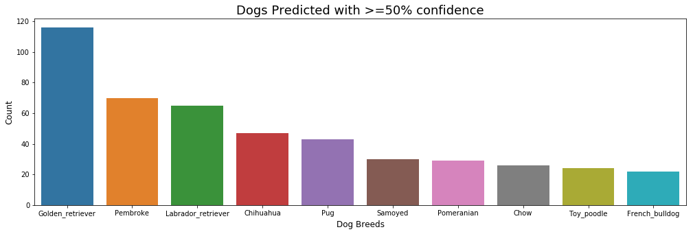

```python
new_d = dtt['first_prediction'].value_counts()[0:10]
plt.figure(figsize = (17,5))
ax = sns.barplot(x = new_d.index, y = new_d, data = dtt);
plt.xlabel("Dog Breeds",fontsize = 12);
plt.ylabel("Count",fontsize = 12);
plt.title("Dogs Predicted with >=50% confidence",fontsize = 18);
```

###### We create a dataframe named new_frame to capture the top 10 breeds with >= 50% prediction confidence

```python
new_frame = twitter_data[(twitter_data['first_prediction'] == 'Golden_retriever') |
                         (twitter_data['first_prediction'] == 'Pembroke') |
                         (twitter_data['first_prediction'] == 'Labrador_retriever') |
                         (twitter_data['first_prediction'] == 'Chihuahua') |
                         (twitter_data['first_prediction'] == 'Pug') |
                         (twitter_data['first_prediction'] == 'Samoyed') |
                         (twitter_data['first_prediction'] == 'Pomeranian') |
                         (twitter_data['first_prediction'] == 'Chow') |
                         (twitter_data['first_prediction'] == 'Toy_poodle') |
                         (twitter_data['first_prediction'] == 'French_bulldog')]
```

```python
new_frame
```

|  | tweet_id | text | jpg_url | date | weekday | name | dog_class | favorite_count | retweet_count | rating_numerator | rating_denominator | first_prediction | first_confidence | p1_dog | second_prediction | second_confidence | p2_dog | third_prediction | third_confidence | p3_dog |
| --- | --- | --- | --- | --- | --- | --- | --- | --- | --- | --- | --- | --- | --- | --- | --- | --- | --- | --- | --- | --- |
| 1 | 892177421306343426 | This is Tilly. She's just checking pup on you.... | https://pbs.twimg.com/media/DGGmoV4XsAAUL6n.jpg | 2017-08-01 | Tuesday | Tilly | NaN | 29318 | 5300 | 13 | 10 | Chihuahua | 0.323581 | True | Pekinese | 0.090647 | True | Papillon | 0.068957 | True |
| 2 | 891815181378084864 | This is Archie. He is a rare Norwegian Pouncin... | https://pbs.twimg.com/media/DGBdLU1WsAANxJ9.jpg | 2017-07-31 | Monday | Archie | NaN | 22045 | 3477 | 12 | 10 | Chihuahua | 0.716012 | True | Malamute | 0.078253 | True | Kelpie | 0.031379 | True |
| 7 | 890729181411237888 | When you watch your owner call another dog a g... | https://pbs.twimg.com/media/DFyBahAVwAAhUTd.jpg | 2017-07-28 | Friday | None | NaN | 56857 | 15752 | 13 | 10 | Pomeranian | 0.566142 | True | Eskimo_dog | 0.178406 | True | Pembroke | 0.076507 | True |
| 9 | 890240255349198849 | This is Cassie. She is a college pup. Studying... | https://pbs.twimg.com/media/DFrEyVuW0AAO3t9.jpg | 2017-07-26 | Wednesday | Cassie | doggo | 27953 | 6097 | 14 | 10 | Pembroke | 0.511319 | True | Cardigan | 0.451038 | True | Chihuahua | 0.029248 | True |
| 10 | 890006608113172480 | This is Koda. He is a South Australian decksha... | https://pbs.twimg.com/media/DFnwSY4WAAAMliS.jpg | 2017-07-26 | Wednesday | Koda | NaN | 27034 | 6150 | 13 | 10 | Samoyed | 0.957979 | True | Pomeranian | 0.013884 | True | Chow | 0.008167 | True |
| 11 | 889880896479866881 | This is Bruno. He is a service shark. Only get... | https://pbs.twimg.com/media/DFl99B1WsAITKsg.jpg | 2017-07-25 | Tuesday | Bruno | NaN | 24562 | 4165 | 13 | 10 | French_bulldog | 0.377417 | True | Labrador_retriever | 0.151317 | True | Muzzle | 0.082981 | False |
| 12 | 889665388333682689 | Here's a puppo that seems to be on the fence a... | https://pbs.twimg.com/media/DFi579UWsAAatzw.jpg | 2017-07-25 | Tuesday | None | puppo | 42046 | 8347 | 13 | 10 | Pembroke | 0.966327 | True | Cardigan | 0.027356 | True | Basenji | 0.004633 | True |
| 13 | 889638837579907072 | This is Ted. He does his best. Sometimes that'... | https://pbs.twimg.com/media/DFihzFfXsAYGDPR.jpg | 2017-07-25 | Tuesday | Ted | NaN | 23668 | 3712 | 12 | 10 | French_bulldog | 0.991650 | True | Boxer | 0.002129 | True | Staffordshire_bullterrier | 0.001498 | True |
| 14 | 889531135344209921 | This is Stuart. He's sporting his favorite fan... | https://pbs.twimg.com/media/DFg_2PVW0AEHN3p.jpg | 2017-07-24 | Monday | Stuart | puppo | 13348 | 1880 | 13 | 10 | Golden_retriever | 0.953442 | True | Labrador_retriever | 0.013834 | True | Redbone | 0.007958 | True |
| 16 | 888917238123831296 | This is Jim. He found a fren. Taught him how t... | https://pbs.twimg.com/media/DFYRgsOUQAARGhO.jpg | 2017-07-23 | Sunday | Jim | NaN | 25630 | 3759 | 12 | 10 | Golden_retriever | 0.714719 | True | Tibetan_mastiff | 0.120184 | True | Labrador_retriever | 0.105506 | True |
| 17 | 888804989199671297 | This is Zeke. He has a new stick. Very proud o... | https://pbs.twimg.com/media/DFWra-3VYAA2piG.jpg | 2017-07-22 | Saturday | Zeke | NaN | 22458 | 3534 | 13 | 10 | Golden_retriever | 0.469760 | True | Labrador_retriever | 0.184172 | True | English_setter | 0.073482 | True |
| 19 | 888078434458587136 | This is Gerald. He was just told he didn't get... | https://pbs.twimg.com/media/DFMWn56WsAAkA7B.jpg | 2017-07-20 | Thursday | Gerald | NaN | 19147 | 2892 | 12 | 10 | French_bulldog | 0.995026 | True | Pug | 0.000932 | True | Bull_mastiff | 0.000903 | True |
| 22 | 887473957103951883 | This is Canela. She attempted some fancy porch... | https://pbs.twimg.com/media/DFDw2tyUQAAAFke.jpg | 2017-07-19 | Wednesday | Canela | NaN | 60177 | 15018 | 13 | 10 | Pembroke | 0.809197 | True | Rhodesian_ridgeback | 0.054950 | True | Beagle | 0.038915 | True |
| 24 | 887101392804085760 | This... is a Jubilant Antarctic House Bear. We... | https://pbs.twimg.com/media/DE-eAq6UwAA-jaE.jpg | 2017-07-18 | Tuesday | None | NaN | 26974 | 4986 | 12 | 10 | Samoyed | 0.733942 | True | Eskimo_dog | 0.035029 | True | Staffordshire_bullterrier | 0.029705 | True |
| 25 | 886983233522544640 | This is Maya. She's very shy. Rarely leaves he... | https://pbs.twimg.com/media/DE8yicJW0AAAvBJ.jpg | 2017-07-17 | Monday | Maya | NaN | 30379 | 6311 | 13 | 10 | Chihuahua | 0.793469 | True | Toy_terrier | 0.143528 | True | Can_opener | 0.032253 | False |
| 28 | 886366144734445568 | This is Roscoe. Another pupper fallen victim t... | https://pbs.twimg.com/media/DE0BTnQUwAApKEH.jpg | 2017-07-15 | Saturday | Roscoe | pupper | 18544 | 2629 | 12 | 10 | French_bulldog | 0.999201 | True | Chihuahua | 0.000361 | True | Boston_bull | 0.000076 | True |
| 29 | 886258384151887873 | This is Waffles. His doggles are pupside down.... | https://pbs.twimg.com/media/DEyfTG4UMAE4aE9.jpg | 2017-07-15 | Saturday | Waffles | NaN | 24518 | 5284 | 13 | 10 | Pug | 0.943575 | True | Shower_cap | 0.025286 | False | Siamese_cat | 0.002849 | False |
| 31 | 885528943205470208 | This is Maisey. She fell asleep mid-excavation... | https://pbs.twimg.com/media/DEoH3yvXgAAzQtS.jpg | 2017-07-13 | Thursday | Maisey | NaN | 31590 | 5325 | 13 | 10 | Pug | 0.369275 | True | Labrador_retriever | 0.265835 | True | Kuvasz | 0.134697 | True |
| 34 | 884876753390489601 | This is Lola. It's her first time outside. Mus... | https://pbs.twimg.com/media/DEe2tZXXkAAwyX3.jpg | 2017-07-11 | Tuesday | Lola | NaN | 24378 | 4673 | 13 | 10 | Chow | 0.822103 | True | Norwich_terrier | 0.106075 | True | Norfolk_terrier | 0.037348 | True |
| 35 | 884562892145688576 | This is Kevin. He's just so happy. 13/10 what ... | https://pbs.twimg.com/media/DEaZQkfXUAEC7qB.jpg | 2017-07-11 | Tuesday | Kevin | NaN | 21316 | 3907 | 13 | 10 | Pug | 0.546406 | True | French_bulldog | 0.404291 | True | Brabancon_griffon | 0.044002 | True |
| 36 | 884441805382717440 | I present to you, Pup in Hat. Pup in Hat is gr... | https://pbs.twimg.com/media/DEYrIZwWsAA2Wo5.jpg | 2017-07-10 | Monday | None | NaN | 23857 | 4789 | 14 | 10 | Pembroke | 0.993225 | True | Cardigan | 0.003216 | True | Chihuahua | 0.002081 | True |
| 39 | 883482846933004288 | This is Bella. She hopes her smile made you sm... | https://pbs.twimg.com/media/DELC9dZXUAADqUk.jpg | 2017-07-08 | Saturday | Bella | NaN | 40203 | 8268 | 5 | 10 | Golden_retriever | 0.943082 | True | Labrador_retriever | 0.032409 | True | Kuvasz | 0.005501 | True |
| 40 | 883360690899218434 | Meet Grizzwald. He may be the floofiest floofe... | https://pbs.twimg.com/media/DEJT3FeXoAAtwUy.jpg | 2017-07-07 | Friday | Grizzwald | floofer | 19942 | 3077 | 13 | 10 | Chow | 0.987997 | True | Tibetan_mastiff | 0.007099 | True | Newfoundland | 0.002140 | True |
| 41 | 883117836046086144 | Please only send dogs. We don't rate mechanics... | https://pbs.twimg.com/media/DEF2-_hXoAAs62q.jpg | 2017-07-07 | Friday | None | NaN | 32506 | 5533 | 13 | 10 | Golden_retriever | 0.949562 | True | Labrador_retriever | 0.045948 | True | Kuvasz | 0.002471 | True |
| 43 | 882762694511734784 | This is Gus. He's quite the cheeky pupper. Alr... | https://pbs.twimg.com/media/DEAz_HHXsAA-p_z.jpg | 2017-07-06 | Thursday | Gus | pupper | 24785 | 4094 | 12 | 10 | Labrador_retriever | 0.850050 | True | Chesapeake_bay_retriever | 0.074257 | True | Flat-coated_retriever | 0.015579 | True |
| 44 | 882627270321602560 | This is Stanley. He has his first swim lesson ... | https://pbs.twimg.com/media/DD-40X3WAAAJPU5.jpg | 2017-07-05 | Wednesday | Stanley | NaN | 24600 | 5061 | 13 | 10 | Pembroke | 0.542982 | True | Chihuahua | 0.251988 | True | Cardigan | 0.107699 | True |
| 45 | 882268110199369728 | This is Alfy. You're witnessing his first wate... | https://pbs.twimg.com/media/DD5yKdPW0AArzX8.jpg | 2017-07-04 | Tuesday | Alfy | NaN | 39190 | 9628 | 13 | 10 | Golden_retriever | 0.762211 | True | Labrador_retriever | 0.098985 | True | Cocker_spaniel | 0.017199 | True |
| 49 | 881536004380872706 | Here is a pupper approaching maximum borkdrive... | https://pbs.twimg.com/ext_tw_video_thumb/88153... | 2017-07-02 | Sunday | A | pupper | 43438 | 13395 | 14 | 10 | Samoyed | 0.281463 | True | Angora | 0.272066 | False | Persian_cat | 0.114854 | False |
| 52 | 880872448815771648 | Ugh not again. We only rate dogs. Please don't... | https://pbs.twimg.com/media/DDl8zzJW0AAisCJ.jpg | 2017-06-30 | Friday | None | NaN | 18713 | 3199 | 12 | 10 | Pembroke | 0.791416 | True | Norwich_terrier | 0.061393 | True | Chihuahua | 0.033726 | True |
| 53 | 880465832366813184 | This is Bella. She had her first beach experie... | https://pbs.twimg.com/media/DDgK-J4XUAIEV9W.jpg | 2017-06-29 | Thursday | Bella | NaN | 25031 | 5211 | 12 | 10 | Golden_retriever | 0.913255 | True | Labrador_retriever | 0.026329 | True | Cocker_spaniel | 0.009371 | True |
| ... | ... | ... | ... | ... | ... | ... | ... | ... | ... | ... | ... | ... | ... | ... | ... | ... | ... | ... | ... | ... |
| 1874 | 668204964695683073 | This is Ron. Ron's currently experiencing a br... | https://pbs.twimg.com/media/CUXw3qHWoAAk8HJ.jpg | 2015-11-21 | Saturday | Ron | NaN | 489 | 173 | 8 | 10 | Labrador_retriever | 0.655180 | True | Golden_retriever | 0.107884 | True | Chesapeake_bay_retriever | 0.065835 | True |
| 1876 | 668171859951755264 | This is a Trans Siberian Kellogg named Alfonso... | https://pbs.twimg.com/media/CUXSwy8W4AA6uet.jpg | 2015-11-21 | Saturday | A | NaN | 425 | 162 | 7 | 10 | Chihuahua | 0.664834 | True | Cowboy_boot | 0.060343 | False | Giant_panda | 0.059838 | False |
| 1879 | 668113020489474048 | This is Alfie. He's that one hypocritical gym ... | https://pbs.twimg.com/media/CUWdPsqWcAERQVv.jpg | 2015-11-21 | Saturday | Alfie | NaN | 585 | 208 | 6 | 10 | Pembroke | 0.548896 | True | Cardigan | 0.191101 | True | Collie | 0.059814 | True |
| 1881 | 667924896115245057 | This is Jiminy. He has always wanted to be a c... | https://pbs.twimg.com/media/CUTyJpHWcAATl0O.jpg | 2015-11-21 | Saturday | Jiminy | NaN | 264 | 95 | 9 | 10 | Labrador_retriever | 0.209051 | True | Hog | 0.203980 | False | Newfoundland | 0.165914 | True |
| 1885 | 667886921285246976 | This is Erik. He's fucken massive. But also ki... | https://pbs.twimg.com/media/CUTPnPCW4AI7R0y.jpg | 2015-11-21 | Saturday | Erik | NaN | 1646 | 908 | 11 | 10 | Pomeranian | 0.800432 | True | Pekinese | 0.168445 | True | Chihuahua | 0.008950 | True |
| 1901 | 667546741521195010 | Here is George. George took a selfie of his ne... | https://pbs.twimg.com/media/CUOaOWXWcAA0_Jy.jpg | 2015-11-20 | Friday | George | NaN | 303 | 107 | 9 | 10 | Toy_poodle | 0.787424 | True | Miniature_poodle | 0.202225 | True | Teddy | 0.004047 | False |
| 1902 | 667544320556335104 | This is Kial. Kial is either wearing a cape, w... | https://pbs.twimg.com/media/CUOYBbbWIAAXQGU.jpg | 2015-11-20 | Friday | Kial | NaN | 762 | 459 | 10 | 10 | Pomeranian | 0.412893 | True | Pembroke | 0.312958 | True | Chihuahua | 0.071960 | True |
| 1904 | 667534815156183040 | This is Frank (pronounced "Fronq"). Too many b... | https://pbs.twimg.com/media/CUOPYI5UcAAj_nO.jpg | 2015-11-20 | Friday | Frank | NaN | 718 | 446 | 8 | 10 | Pembroke | 0.435254 | True | Cardigan | 0.307407 | True | Cocker_spaniel | 0.033158 | True |
| 1905 | 667530908589760512 | Meet Naphaniel. He doesn't necessarily enjoy h... | https://pbs.twimg.com/media/CUOL0uGUkAAx7yh.jpg | 2015-11-20 | Friday | Naphaniel | NaN | 412 | 206 | 10 | 10 | Golden_retriever | 0.633037 | True | Kuvasz | 0.146391 | True | Labrador_retriever | 0.046184 | True |
| 1909 | 667502640335572993 | Say hello to Hall and Oates. Oates is winking ... | https://pbs.twimg.com/media/CUNyHTMUYAAQVch.jpg | 2015-11-20 | Friday | Hall | NaN | 485 | 194 | 11 | 10 | Labrador_retriever | 0.996709 | True | Golden_retriever | 0.001688 | True | Beagle | 0.000712 | True |
| 1910 | 667495797102141441 | This is Philippe from Soviet Russia. Commandin... | https://pbs.twimg.com/media/CUNr4-7UwAAg2lq.jpg | 2015-11-20 | Friday | Philippe | NaN | 458 | 231 | 9 | 10 | Chihuahua | 0.143957 | True | Christmas_stocking | 0.118651 | False | Ski_mask | 0.092482 | False |
| 1912 | 667470559035432960 | This is a northern Wahoo named Kohl. He runs t... | https://pbs.twimg.com/media/CUNU78YWEAECmpB.jpg | 2015-11-19 | Thursday | A | NaN | 225 | 85 | 11 | 10 | Toy_poodle | 0.304175 | True | Pug | 0.223427 | True | Lakeland_terrier | 0.073316 | True |
| 1914 | 667453023279554560 | Meet Cupcake. I would do unspeakable things fo... | https://pbs.twimg.com/media/CUNE_OSUwAAdHhX.jpg | 2015-11-19 | Thursday | Cupcake | NaN | 279 | 74 | 11 | 10 | Labrador_retriever | 0.825670 | True | French_bulldog | 0.056639 | True | Staffordshire_bullterrier | 0.054018 | True |
| 1921 | 667211855547486208 | This is Genevieve. She is a golden retriever c... | https://pbs.twimg.com/media/CUJppKJWoAA75NP.jpg | 2015-11-19 | Thursday | Genevieve | NaN | 425 | 209 | 9 | 10 | Golden_retriever | 0.462556 | True | Labrador_retriever | 0.454937 | True | Kuvasz | 0.024193 | True |
| 1925 | 667182792070062081 | This is Timison. He just told an awful joke bu... | https://pbs.twimg.com/media/CUJPNjOWsAAZRqP.jpg | 2015-11-19 | Thursday | Timison | NaN | 12546 | 5275 | 10 | 10 | Golden_retriever | 0.949892 | True | Irish_setter | 0.010564 | True | Chesapeake_bay_retriever | 0.005821 | True |
| 1928 | 667174963120574464 | This is Clarence. His face says he doesn't wan... | https://pbs.twimg.com/media/CUJIFoJWsAAL3Dc.jpg | 2015-11-19 | Thursday | Clarence | NaN | 218 | 70 | 9 | 10 | Toy_poodle | 0.266437 | True | Chihuahua | 0.243223 | True | Bluetick | 0.072806 | True |
| 1931 | 667160273090932737 | This is Bradlay. He is a Ronaldinho Matsuyama ... | https://pbs.twimg.com/media/CUI6uuaW4AAvCIs.jpg | 2015-11-19 | Thursday | Bradlay | NaN | 219 | 50 | 11 | 10 | Golden_retriever | 0.471351 | True | Miniature_poodle | 0.091992 | True | Standard_poodle | 0.087385 | True |
| 1932 | 667152164079423490 | This is Pipsy. He is a fluffball. Enjoys trave... | https://pbs.twimg.com/media/CUIzWk_UwAAfUNq.jpg | 2015-11-19 | Thursday | Pipsy | NaN | 42279 | 14610 | 12 | 10 | Toy_poodle | 0.535411 | True | Pomeranian | 0.087544 | True | Miniature_poodle | 0.062050 | True |
| 1934 | 667119796878725120 | This is Gabe. He is a southern Baklava. Gabe h... | https://pbs.twimg.com/media/CUIV6F7XIAA1tAM.jpg | 2015-11-18 | Wednesday | Gabe | NaN | 286 | 106 | 10 | 10 | Pembroke | 0.741563 | True | Chihuahua | 0.057866 | True | Toy_poodle | 0.039125 | True |
| 1935 | 667090893657276420 | This is Clybe. He is an Anemone Valdez. One ea... | https://pbs.twimg.com/media/CUH7oLuUsAELWib.jpg | 2015-11-18 | Wednesday | Clybe | NaN | 287 | 106 | 7 | 10 | Chihuahua | 0.959514 | True | Italian_greyhound | 0.005370 | True | Pomeranian | 0.002641 | True |
| 1936 | 667073648344346624 | Here is Dave. He is actually just a skinny leg... | https://pbs.twimg.com/media/CUHr8WbWEAEBPgf.jpg | 2015-11-18 | Wednesday | Dave | NaN | 351 | 104 | 10 | 10 | Chihuahua | 0.483682 | True | Pug | 0.092494 | True | Brabancon_griffon | 0.057495 | True |
| 1939 | 667044094246576128 | 12/10 gimme now https://t.co/QZAnwgnOMB | https://pbs.twimg.com/media/CUHREBXXAAE6A9b.jpg | 2015-11-18 | Wednesday | None | NaN | 163 | 43 | 12 | 10 | Golden_retriever | 0.765266 | True | Labrador_retriever | 0.206694 | True | Seat_belt | 0.010667 | False |
| 1952 | 666701168228331520 | This is a golden Buckminsterfullerene named Jo... | https://pbs.twimg.com/media/CUCZLHlUAAAeAig.jpg | 2015-11-17 | Tuesday | A | NaN | 371 | 182 | 8 | 10 | Labrador_retriever | 0.887707 | True | Chihuahua | 0.029307 | True | French_bulldog | 0.020756 | True |
| 1958 | 666437273139982337 | Here we see a lone northeastern Cumberbatch. H... | https://pbs.twimg.com/media/CT-pKmRWIAAxUWj.jpg | 2015-11-17 | Tuesday | None | NaN | 106 | 40 | 7 | 10 | Chihuahua | 0.671853 | True | Beagle | 0.124680 | True | Saluki | 0.044094 | True |
| 1961 | 666428276349472768 | Here we have an Austrian Pulitzer. Collectors ... | https://pbs.twimg.com/media/CT-g-0DUwAEQdSn.jpg | 2015-11-17 | Tuesday | None | NaN | 139 | 67 | 7 | 10 | Pembroke | 0.371361 | True | Chow | 0.249394 | True | Pomeranian | 0.241878 | True |
| 1966 | 666396247373291520 | Oh goodness. A super rare northeast Qdoba kang... | https://pbs.twimg.com/media/CT-D2ZHWIAA3gK1.jpg | 2015-11-16 | Monday | None | NaN | 147 | 69 | 9 | 10 | Chihuahua | 0.978108 | True | Toy_terrier | 0.009397 | True | Papillon | 0.004577 | True |
| 1970 | 666345417576210432 | Look at this jokester thinking seat belt laws ... | https://pbs.twimg.com/media/CT9Vn7PWoAA_ZCM.jpg | 2015-11-16 | Monday | None | NaN | 245 | 124 | 10 | 10 | Golden_retriever | 0.858744 | True | Chesapeake_bay_retriever | 0.054787 | True | Labrador_retriever | 0.014241 | True |
| 1980 | 666082916733198337 | Here we have a well-established sunblockerspan... | https://pbs.twimg.com/media/CT5m4VGWEAAtKc8.jpg | 2015-11-16 | Monday | None | NaN | 93 | 37 | 6 | 10 | Pug | 0.489814 | True | Bull_mastiff | 0.404722 | True | French_bulldog | 0.048960 | True |
| 1983 | 666063827256086533 | This is the happiest dog you will ever see. Ve... | https://pbs.twimg.com/media/CT5Vg_wXIAAXfnj.jpg | 2015-11-16 | Monday | The | NaN | 399 | 180 | 10 | 10 | Golden_retriever | 0.775930 | True | Tibetan_mastiff | 0.093718 | True | Labrador_retriever | 0.072427 | True |
| 1986 | 666055525042405380 | Here is a Siberian heavily armored polar bear ... | https://pbs.twimg.com/media/CT5N9tpXIAAifs1.jpg | 2015-11-16 | Monday | A | NaN | 367 | 196 | 10 | 10 | Chow | 0.692517 | True | Tibetan_mastiff | 0.058279 | True | Fur_coat | 0.054449 | False |

638 rows × 20 columns

```python
pop_dog_breed = new_frame.groupby('first_prediction')['retweet_count'].sum().sort_values()
pop_dog_breed
```

```
first_prediction
Toy_poodle             71578
Pug                    78796
Pomeranian             87045
Chow                   95467
French_bulldog         98103
Samoyed               141591
Chihuahua             183037
Pembroke              227438
Labrador_retriever    280442
Golden_retriever      408736
Name: retweet_count, dtype: int64
```

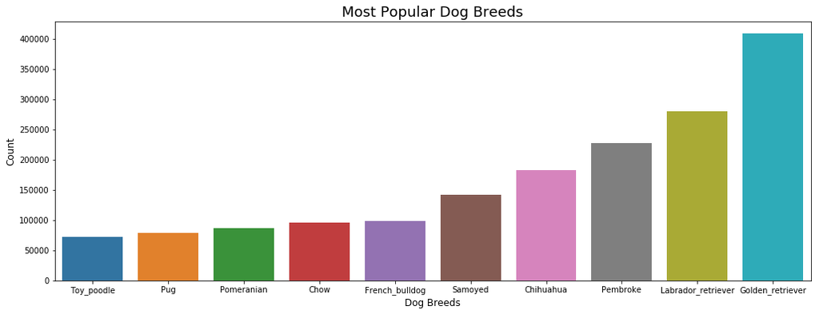

```python
plt.figure(figsize = (17,6))
ax = sns.barplot(x = pop_dog_breed.index, y = pop_dog_breed);
plt.xlabel("Dog Breeds",fontsize = 12);
plt.ylabel("Count",fontsize = 12);
plt.title("Most Popular Dog Breeds",fontsize = 18);
```

```python
fav_dog_breed = new_frame.groupby('first_prediction')['favorite_count'].sum().sort_values()
fav_dog_breed
```

```
first_prediction
Toy_poodle             202549
Pomeranian             264515
Pug                    271204
Chow                   353458
French_bulldog         408652
Samoyed                447879
Chihuahua              598256
Pembroke               867411
Labrador_retriever     910429
Golden_retriever      1475533
Name: favorite_count, dtype: int64
```

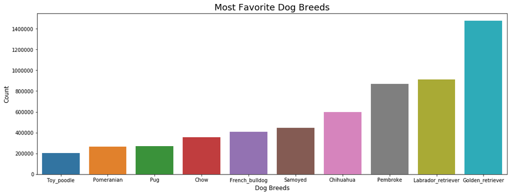

```python
plt.figure(figsize = (17,6))
ax = sns.barplot(x = fav_dog_breed.index, y = fav_dog_breed);
plt.xlabel("Dog Breeds",fontsize = 12);
plt.ylabel("Count",fontsize = 12);
plt.title("Most Favorite Dog Breeds",fontsize = 18);
```

```python
fav_dog_breed.corr(pop_dog_breed)
```

```
0.99170380613792974
```

#### Retweet_Count and Favorite_Count on Dog_Class

Most loved dog_class and most popular dog_class

```python
pop_dog = twitter_data.groupby('dog_class')['retweet_count'].sum()[-4:].sort_values()
pop_dog
```

```
dog_class
floofer     30673
puppo      133248
pupper     387500
doggo      401279
Name: retweet_count, dtype: int64
```

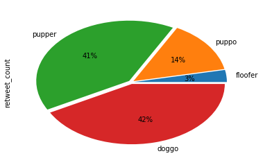

```python
explode = (0.03,0.03,0.03,0.03)
pop_dog.plot(kind = 'pie',autopct='%1.0f%%', explode = explode)
```

```python
fav_dog = twitter_data.groupby('dog_class')['favorite_count'].sum()[-4:].sort_values()
fav_dog
```

```
dog_class
floofer      93378
puppo       472450
doggo      1199391
pupper     1259246
Name: favorite_count, dtype: int64
```

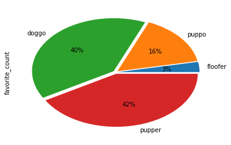

```python
explode = (0.03,0.03,0.03,0.03)
fav_dog.plot(kind = 'pie',autopct='%1.0f%%', explode = explode)
```

The most favorite and most popular dog classes are doggo and pupper with a combined score of over 80%

#### Relationship between favorite Count, retweet Count and rating Numerator

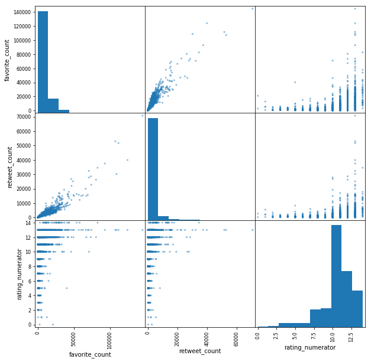

```python
tw = twitter_data[["favorite_count","retweet_count", "rating_numerator"]]
pd.plotting.scatter_matrix(tw, figsize = (10,10));
```

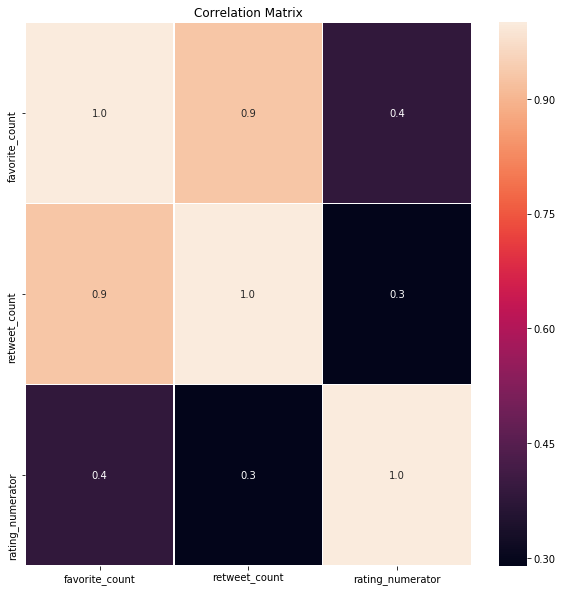

```python
#Plotting correlation plot for Retweet Count, Favorite Count and Ratings to check relationships
f,ax = plt.subplots(figsize=(10, 10))
sns.heatmap(twitter_data[['favorite_count', 'retweet_count','rating_numerator']].corr(), annot=True, linewidths=.5, fmt= '.1f')
plt.title('Correlation Matrix');
```

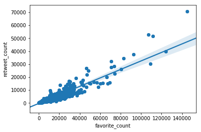

```python
plt.scatter(twitter_data['favorite_count'], twitter_data['retweet_count'])
sns.regplot(x = "favorite_count", y = "retweet_count", data = twitter_data);
```

```python
twitter_data['favorite_count'].corr(twitter_data['retweet_count'])
```

```
0.92848273497721712
```

### Insights:

1. Only 937 dogs out of 1477 predicted dogs, were predicted with confidence greater than 50%. In second and third predictions, no dog was predicted with confidence greater than 50%
2. The most favorite and most popular dog classes are doggo and pupper with a combined score of over 80%
3. Golden_retriever, Labrador_retriever, and Pembroke are the most popular and favorite dog breeds
4. There is a very strong positive corelation between favorite_count and retweet_count with about 0.93 correlation score

## Let's View Our Top Dog : Golden Retriever

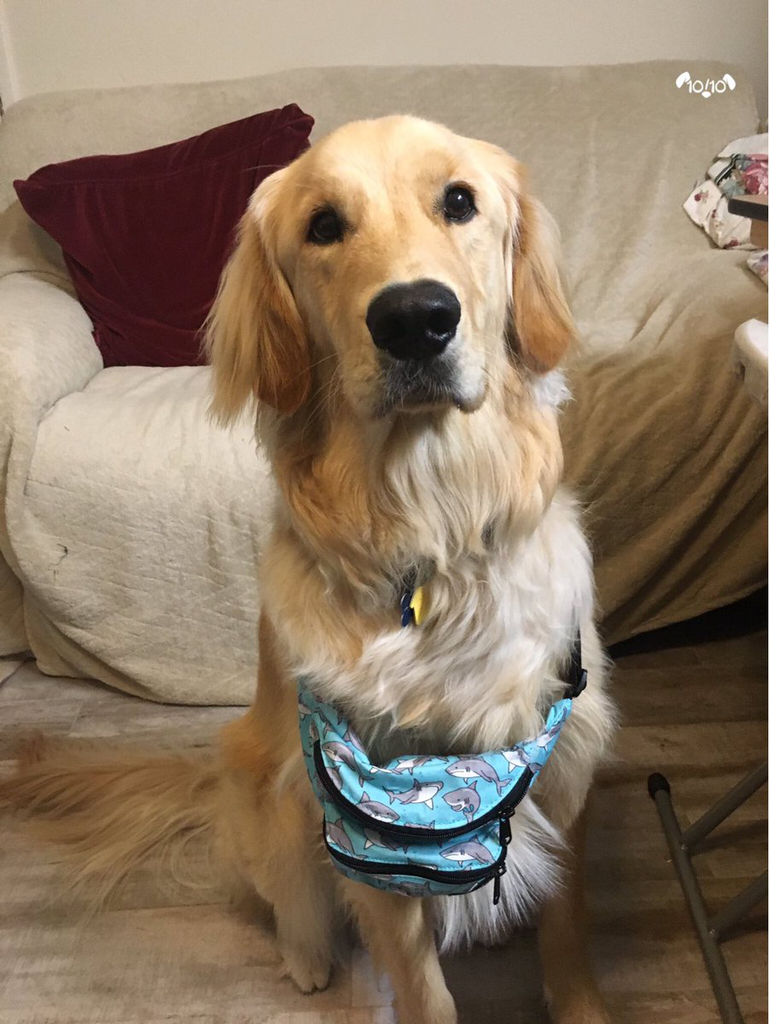

```python
import requests
from PIL import Image
from io import BytesIO

pic = twitter_data.query('first_prediction == "Golden_retriever"')
url = pic.jpg_url.iloc[0]

#Getting the Image of top rated Golden Retriever
url = 'https://pbs.twimg.com/media/DFg_2PVW0AEHN3p.jpg'
response = requests.get(url)
Image.open(BytesIO(response.content))
```